# Oxygen estimation

## 6.7 Individual 168

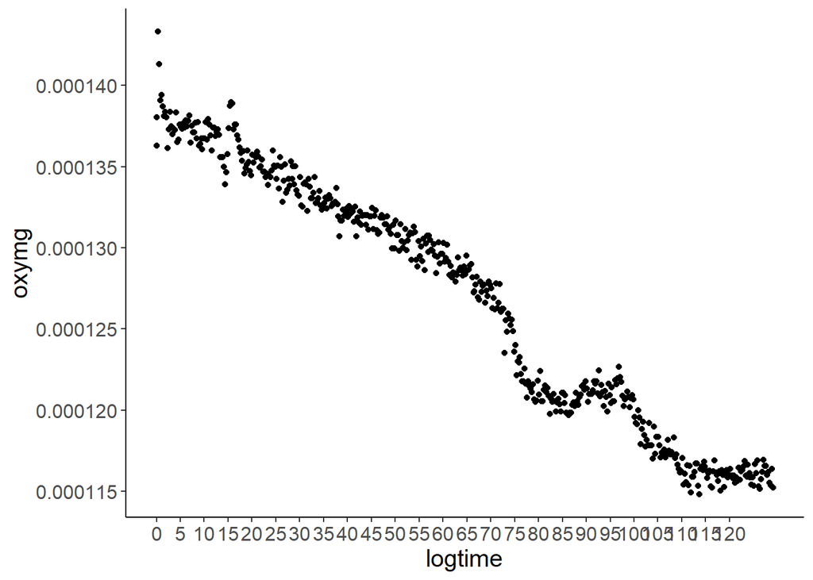

```r
ind168<-oxall %>%
filter(ind=="168")
ggplot(aes(x=logtime, y=oxymg), data=ind168)+geom_point() +theme_classic() + theme(text=element_text(size=15))+scale_x_continuous(breaks = seq(0, 120, by = 5))
```

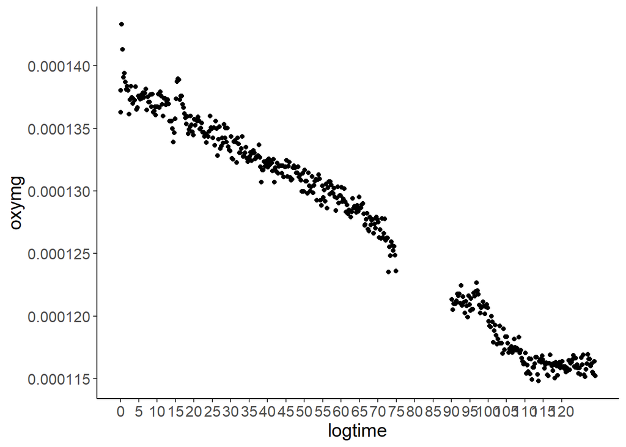

```r
ind168<-ind168 %>%
filter(!between(logtime, 75 ,90))
ggplot(aes(x=logtime, y=oxymg), data=ind168)+geom_point() +theme_classic() + theme(text=element_text(size=15))+scale_x_continuous(breaks = seq(0, 120, by = 5))
```

## 6.8 Individual 267

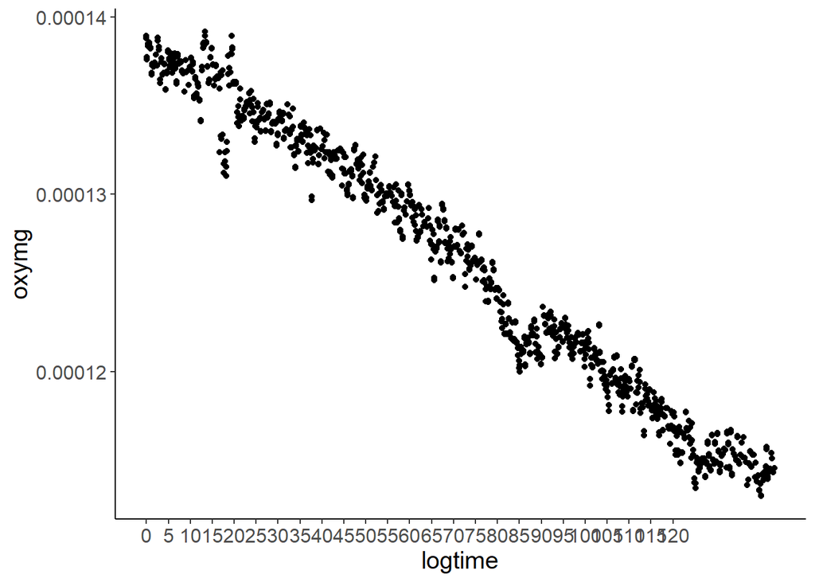

```r
ind267<-oxall %>%
filter(ind=="267")
ggplot(aes(x=logtime, y=oxymg), data=ind267)+geom_point() +theme_classic() + theme(text=element_text(size=15))+scale_x_continuous(breaks = seq(0, 120, by = 5))
```

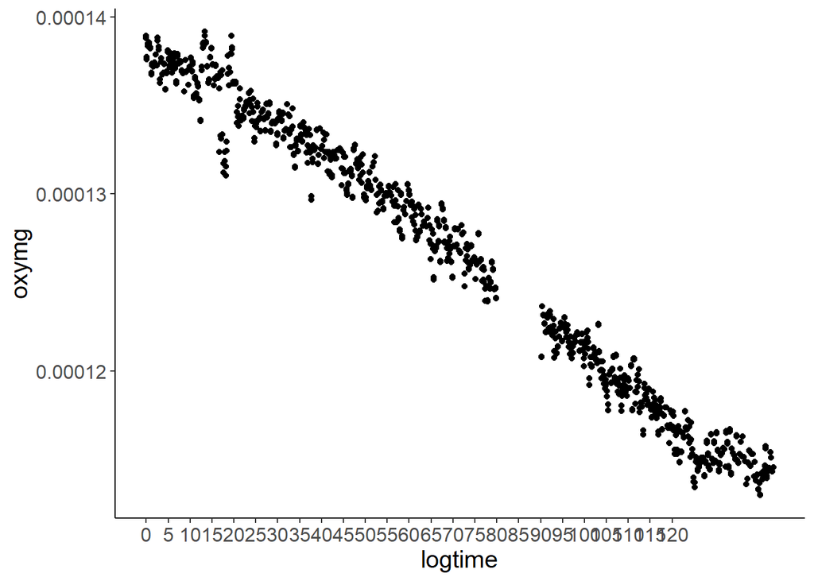

```r
ind267<-ind267 %>%
filter(!between(logtime, 80, 90))
ggplot(aes(x=logtime, y=oxymg), data=ind267)+geom_point() +theme_classic() + theme(text=element_text(size=15))+scale_x_continuous(breaks = seq(0, 120, by = 5))
```

## 6.9 Individual 270

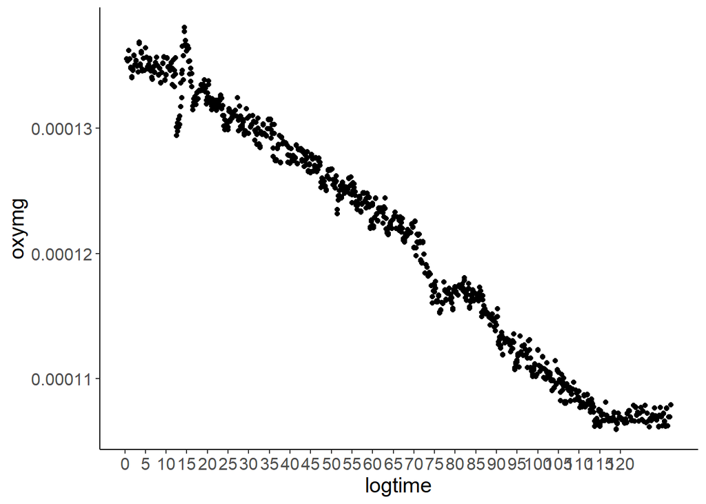

```r
ind270<-oxall %>%
filter(ind=="270")
ggplot(aes(x=logtime, y=oxymg), data=ind270)+geom_point() +theme_classic() + theme(text=element_text(size=15))+scale_x_continuous(breaks = seq(0, 120, by = 5))
```

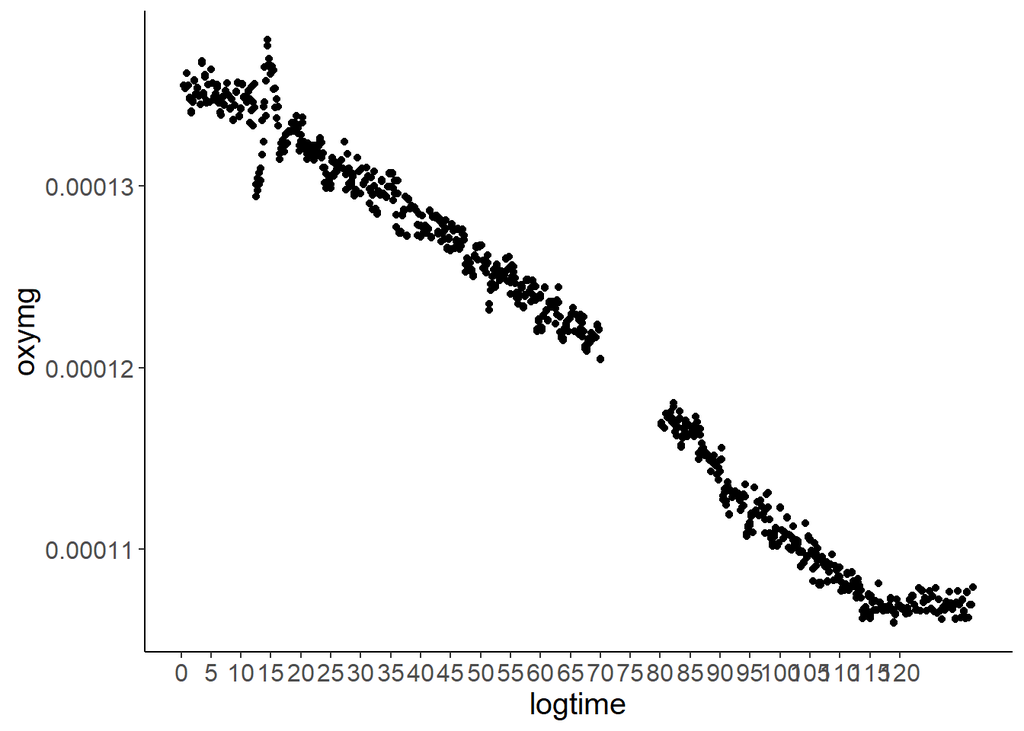

```r
ind270<-ind270 %>%
filter(!between(logtime, 70, 80))
ggplot(aes(x=logtime, y=oxymg), data=ind270)+geom_point() +theme_classic() + theme(text=element_text(size=15))+scale_x_continuous(breaks = seq(0, 120, by = 5))
```

## 6.10 Creating new dataset with trimmed individuals

```r
oxall<-oxall%>%
filter(!ind%in%c("22","83", "131", "136", "159", "168", "267", "270")) %>%
bind_rows(ind22, ind83, ind131, ind136, ind159, ind168, ind267, ind270) %>%
  filter_all(all_vars(!is.infinite(.)))
levels(as.factor(oxall$ind))
```

```
##   [1] "2"   "3"   "4"   "5"   "7"   "10"  "14"  "18"  "22"  "24"  "28"  "29"
##  [13] "30"  "32"  "35"  "36"  "37"  "43"  "48"  "50"  "51"  "54"  "57"  "66"
##  [25] "73"  "79"  "80"  "83"  "85"  "87"  "107" "109" "112" "113" "131" "136"
##  [37] "138" "141" "143" "145" "146" "153" "154" "156" "158" "159" "165" "166"
##  [49] "168" "171" "173" "175" "179" "194" "201" "211" "212" "213" "214" "216"
##  [61] "218" "224" "228" "232" "233" "237" "238" "239" "242" "244" "245" "246"
##  [73] "247" "248" "250" "251" "253" "256" "257" "258" "263" "264" "267" "269"
##  [85] "270" "271" "272" "274" "287" "288" "290" "294" "296" "298" "300" "301"
##  [97] "305" "311" "314" "317" "322" "324" "326" "329" "334" "335" "337" "339"
## [109] "341" "345"
```

```r
write.csv(oxall, "Outputs/oxall_trimmed.csv")
```

## 6.11 Checking the oxygen traces per life stage

> Plotting all the traces separated by life stage and colored by trial

### 6.11.1 Protonymphs

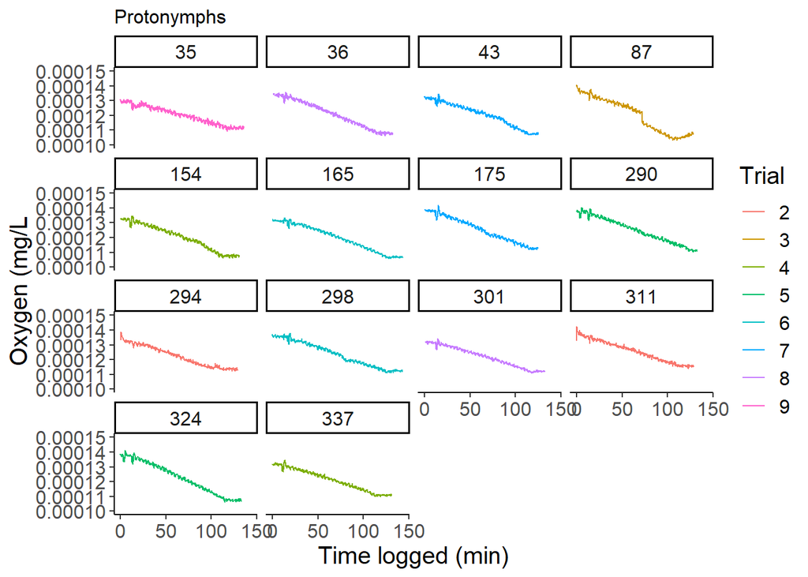

```r
protos <- oxall%>%
  filter(stage=="Protonymph")


ggplot(protos, aes(x=logtime, y=oxymg,group=ind, color=as.factor(trial)))+ #MODIFY FOR EACH TRIAL
  geom_line()+
  theme_classic()+
  theme(text = element_text(size = 15), plot.title = element_text(size = (12)))+
  ylim(0.00010, 0.00015) +
  facet_wrap(~ind)+
  xlab("Time logged (min)")+
  ylab("Oxygen (mg/L")+
  ggtitle("Protonymphs")+
  labs(colour = "Trial")
```

```r
ggsave(plot=last_plot(),filename="OxygenTrace_Protonymphs.jpg",  path="Outputs/Oxygen traces/")
```

### 6.11.2 Deutonymphs

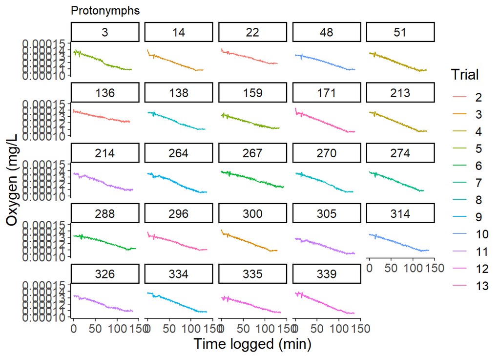

```r
deutos <- oxall%>%
  filter(stage=="Deutonymph")


ggplot(deutos, aes(x=logtime, y=oxymg,group=ind, color=as.factor(trial)))+ #MODIFY FOR EACH TRIAL
  geom_line()+
  theme_classic()+
  theme(text = element_text(size = 15), plot.title = element_text(size = (12)))+
  ylim(0.00010, 0.00015) +
  facet_wrap(~ind)+
  xlab("Time logged (min)")+
  ylab("Oxygen (mg/L")+
  ggtitle("Protonymphs")+
  labs(colour = "Trial")
```

```r
ggsave(plot=last_plot(),filename="OxygenTrace_Deutonymphs.jpg",  path="Outputs/Oxygen traces/")
```

### 6.11.3 Tritonymphs

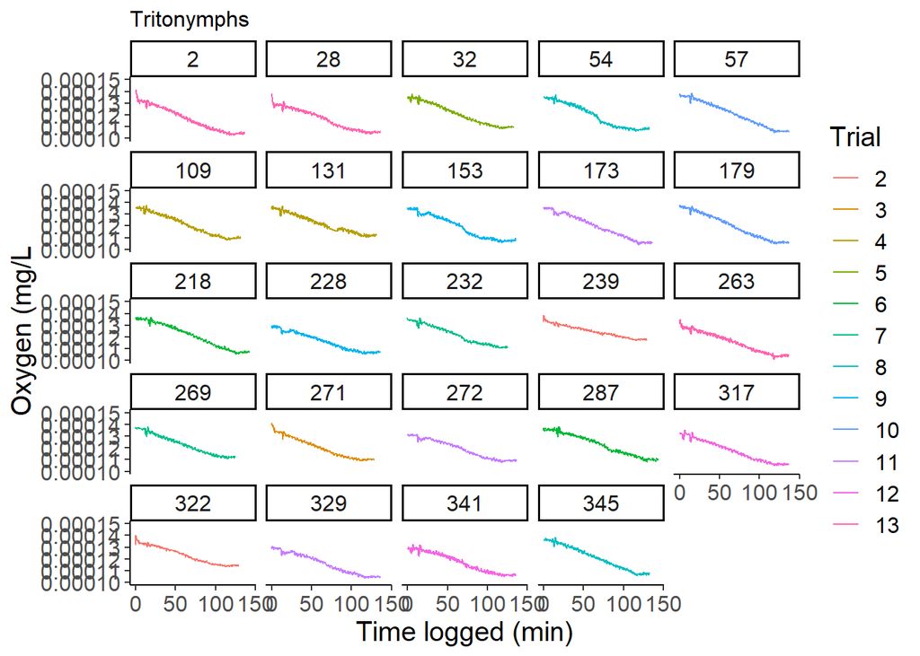

```r
Tritos <- oxall%>%
  filter(stage=="Tritonymph")


ggplot(Tritos, aes(x=logtime, y=oxymg,group=ind, color=as.factor(trial)))+ #MODIFY FOR EACH TRIAL
  geom_line()+
  theme_classic()+
  theme(text = element_text(size = 15), plot.title = element_text(size = (12)))+
  ylim(0.00010, 0.00015) +
  facet_wrap(~ind)+
  xlab("Time logged (min)")+
  ylab("Oxygen (mg/L")+
  ggtitle("Tritonymphs")+
  labs(colour = "Trial")
```

```r
ggsave(plot=last_plot(),filename="OxygenTrace_Tritonymphs.jpg",  path="Outputs/Oxygen traces/")
```

### 6.11.4 Males

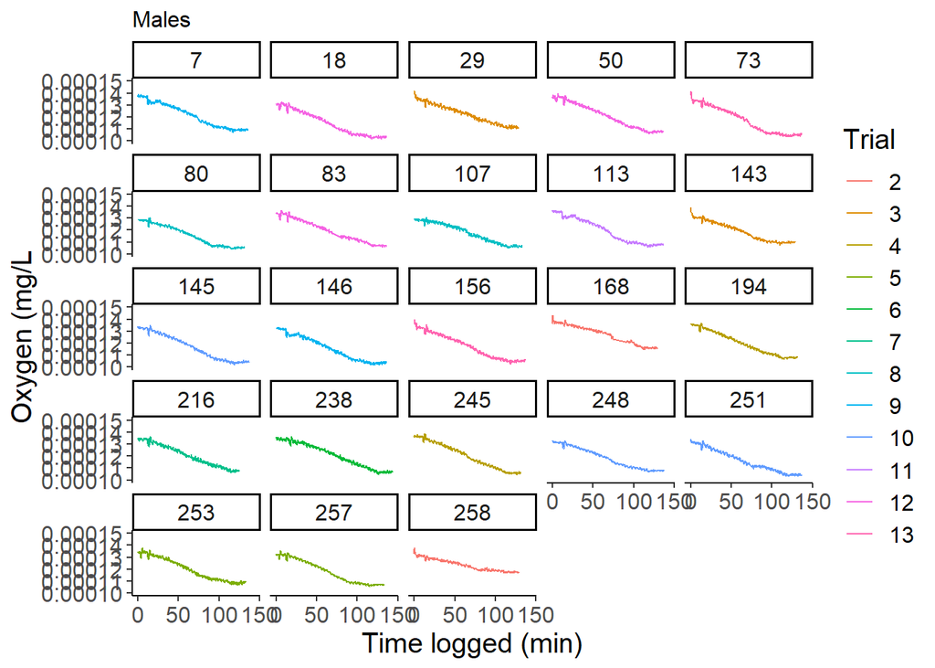

```r
males <- oxall%>%
  filter(stage=="Male")


ggplot(males, aes(x=logtime, y=oxymg,group=ind, color=as.factor(trial)))+ #MODIFY FOR EACH TRIAL
  geom_line()+
  theme_classic()+
  theme(text = element_text(size = 15), plot.title = element_text(size = (12)))+
  ylim(0.00010, 0.00015) +
  facet_wrap(~ind)+
  xlab("Time logged (min)")+
  ylab("Oxygen (mg/L")+
  ggtitle("Males")+
  labs(colour = "Trial")
```

```r
ggsave(plot=last_plot(),filename="OxygenTrace_Males.jpg",  path="Outputs/Oxygen traces/")
```

### 6.11.5 Females

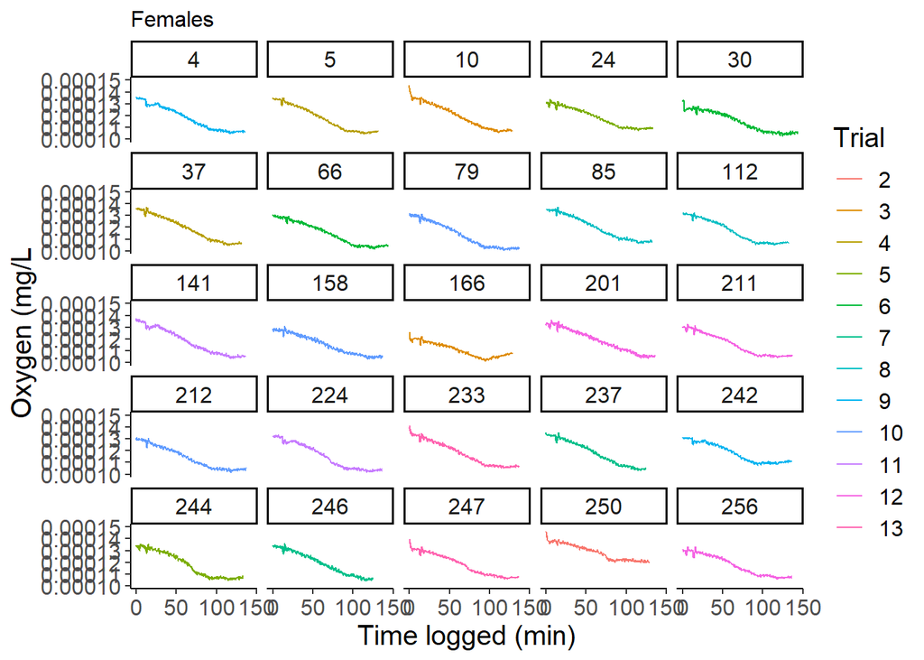

```r
females <- oxall%>%
  filter(stage=="Female")


ggplot(females, aes(x=logtime, y=oxymg,group=ind, color=as.factor(trial)))+ #MODIFY FOR EACH TRIAL
  geom_line()+
  theme_classic()+
  theme(text = element_text(size = 15), plot.title = element_text(size = (12)))+
  ylim(0.00010, 0.00015) +
  facet_wrap(~ind)+
  xlab("Time logged (min)")+
  ylab("Oxygen (mg/L")+
  ggtitle("Females")+
  labs(colour = "Trial")
```

```r
ggsave(plot=last_plot(),filename="OxygenTrace_Females.jpg",  path="Outputs/Oxygen traces/")
```

# 7 Estimating rates of oxygen consumptions: using loops to fit polynomial functions for all individuals

> The following code will do the following steps for each single individual: 1. Fit the polynomial function of 10 degrees to each individual and obtain the adjusted r-square to evaulate model fitting for each individual (file: modelfitting.csv)  
> 2. Plot the oxygen trace and the polynomial function together (Plots in folder named “Function fit”)  
> 3. Get the first and second derivatives for all the traces (file: derivatives.csv)  
> 4. Plot the first and second derivatives (in folders “First derivative plots” and ” Second derivative plots” respectively)  
> 5. Obtaining the inflection points from the second derivative (file: inflections.csv)  
> 6. Making combined figures by merging the traces with the function fitted, the first and second derivatives plots (in folder named “Figure montages”)

## 7.1 Getting data for the loops

```r
oxall<-read.csv("Outputs/oxall_trimmed.csv") #Using the oxygen traces that were trimmed for some individuals that had weird patterns

# Creating separate lists, one for each individual
dat_list<-split(oxall, oxall$ind)
```

## 7.2 1. Adjusting a polynomial function to each individual

```r
# Creating function for fitting model
r2 = function(data) {
fit = lm(oxymg~poly(logtime, 10, raw=TRUE), data = data) #fitting the model
output<-broom::glance(fit) #Getting adjusted r
suma<-broom::tidy(summary(fit)) #Getting parameters for model
merge(output, suma, all=TRUE) #merging both datasets into a single table
}
a<-map_dfr(dat_list, r2, .id = "id") #Provides dataframe with adjusted R
write.csv(a,"./Outputs/modelfitting.csv")
```

## 7.3 2. Plotting the function to the data of each individual

```r
# Creating plots to see the fit
r3 = function(data) {
     fit = lm(oxymg~poly(logtime, 10, raw=TRUE), data = data) #fitting the model
     id<-data[1,12] #Getting ID for each individual

     mypath <- file.path("Outputs/Function fit/",paste("Individual_", id, ".jpg", sep = "")) #defining path and name for each individual

      jpeg(file = mypath, width=20, height=12, units="cm", res=300)

        plot(data$logtime, data$oxymg, pch=19, xlab='Time (min)', ylab='Oxygen(mg)', main=paste("Function fit: Ind", id), cex.lab=1.5, cex.axis=1.25)
lines(data$logtime, predict(fit, data.frame(logtime=data$logtime)), col='red',lwd=2)
dev.off()
     }

map_dfr(dat_list, r3, .id = "id") #This applies the function for each table in the list. this works best for creating plots
```

| id | png |
| --- | --- |
| 2 | 2 |
| 3 | 2 |
| 4 | 2 |
| 5 | 2 |
| 7 | 2 |
| 10 | 2 |
| 14 | 2 |
| 18 | 2 |
| 22 | 2 |
| 24 | 2 |

[output cut: 100 more lines]

## 7.4 3. Getting the first and second derivative for each individual

```r
# Getting the derivatives for each individual
#a2<-split(a, a$id)
r4=function(data){
fit = lm(oxymg~poly(logtime, 10, raw=TRUE), data = data) #fitting the model
coef7<-as.data.frame(fit$coefficients) #Getting summary data into dataframe to extract each coefficient
a0<-coef7[1,1] #extracting each coefficient from the summary
a1<-coef7[2,1]
a2<-coef7[3,1]
a3<-coef7[4,1]
a4<-coef7[5,1]
a5<-coef7[6,1]
a6<-coef7[7,1]
a7<-coef7[8,1]
a8<-coef7[9,1]
a9<-coef7[10,1]
a10<-coef7[11,1]
#x<-ox3$logtime #Values from raw data
x <- seq(0, 125, by=0.20) #Defining the sequence of logtime to use
form7<-expression((a10*x^10)+(a9*x^9)+(a8*x^8)+(a7*x^7)+(a6*x^6)+(a5*x^5)+(a4*x^4)+(a3*x^3)+(a2*x^2)+(a1*x^1)+(a0*x^0)) #Creating the formula of the polynomial function
d7<-D(form7, "x") #getting the first derivative
d7f.data<-as.data.frame(eval(d7, envir=as.data.frame(x))) #Saving output of the first derivative as a data frame
colnames(d7f.data)<-"y1" #defining column name for the first derivative dataframe
d7f.data$logtime<-x #Creating logtime column for first derivative dataframe
d7b<-D(d7, "x") #Getting the second derivative
d7s.data<-as.data.frame(eval(d7b, envir=as.data.frame(x))) #Saving output of the second derivative as a data frame
colnames(d7s.data)<-"y1" #defining column name for the second derivative dataframe
d7s.data$logtime<-x #Creating logtime column for second derivative dataframe
deriv<-list("first"=d7f.data, "second"=d7s.data) #Merging two dataframes together
}
a3<-map_dfr(dat_list, r4, .id = "id") #Creates the list with the values of the two derivatives

## Saving the second derivatives into a single dataframe
write.csv(a3, "./Outputs/derivatives.csv")
```

## 7.5 4. Plotting the first derivative

```r
# Plotting the first derivative

## See #3 above for the rest of the annotations. I will only annotate here what is different from above
r4first=function(data){
  fit = lm(oxymg~poly(logtime, 10, raw=TRUE), data = data)
coef7<-as.data.frame(fit$coefficients)
a0<-coef7[1,1]
a1<-coef7[2,1]
a2<-coef7[3,1]
a3<-coef7[4,1]
a4<-coef7[5,1]
a5<-coef7[6,1]
a6<-coef7[7,1]
a7<-coef7[8,1]
a8<-coef7[9,1]
a9<-coef7[10,1]
a10<-coef7[11,1]
id<-data[1,12]
  #x<-ox3$logtime #Values from raw data
x <- seq(0, 125, by=0.20)
 form7<-expression((a10*x^10)+(a9*x^9)+(a8*x^8)+(a7*x^7)+(a6*x^6)+(a5*x^5)+(a4*x^4)+(a3*x^3)+(a2*x^2)+(a1*x^1)+(a0*x^0))
d7<-D(form7, "x")
d7f.data<-as.data.frame(eval(d7, envir=as.data.frame(x)))
colnames(d7f.data)<-"y1"
d7f.data$logtime<-x

mypath <- file.path("Outputs/First derivative plots/",paste("Individual_", id, ".jpg", sep = "")) #creating name and path for the plot


 jpeg(file = mypath, width=20, height=12, units="cm", res=300) #opens file plot



plot(d7f.data$logtime, d7f.data$y1*-1, pch=19, xlab='Time (min)', ylab='Oxygen consumption rate (mg/min)', main=paste("First derivative: Ind ", id), cex.lab=1.5, cex.axis=1.25, ylim=c((-0.5*10^(-6)), (0.75*10^(-6)) )) #plotting the first derivative
dev.off()
}

map(dat_list, r4first) #created plot for each individual
```

## 7.6 5. Plotting the second derivative

```r
# Plotting the second derivative

#Annotations as the same as #3 and #4, the only difference is that this plot the data for the second derivative but the code is pretty much the same

r4second=function(data){
   fit = lm(oxymg~poly(logtime, 10, raw=TRUE), data = data)
coef7<-as.data.frame(fit$coefficients)
a0<-coef7[1,1]
a1<-coef7[2,1]
a2<-coef7[3,1]
a3<-coef7[4,1]
a4<-coef7[5,1]
a5<-coef7[6,1]
a6<-coef7[7,1]
a7<-coef7[8,1]
a8<-coef7[9,1]
a9<-coef7[10,1]
a10<-coef7[11,1]
id<-data[1,12]
  #x<-ox3$logtime #Values from raw data
  x <- seq(0, 125, by=0.20)
   form7<-expression((a10*x^10)+(a9*x^9)+(a8*x^8)+(a7*x^7)+(a6*x^6)+(a5*x^5)+(a4*x^4)+(a3*x^3)+(a2*x^2)+(a1*x^1)+(a0*x^0))
d7<-D(form7, "x")
d7b<-D(d7, "x")
d7s.data<-as.data.frame(eval(d7b, envir=as.data.frame(x)))
colnames(d7s.data)<-"y1"
d7s.data$logtime<-x

mypath <- file.path("Outputs/Second derivative plots/",paste("Individual_", id, ".jpg", sep = ""))


 jpeg(file = mypath, width=20, height=12, units="cm", res=300)
plot(d7s.data$logtime, d7s.data$y1, pch=19, xlab='Time (min)', ylab='Change oxygen cons. rate (mg/min)', main=paste("Second derivative: Ind", id), cex.lab=1.5, cex.axis=1.25, ylim=c((-0.75e-7),(0.75e-7))) #plots the second derivative
abline(h=0,col="orange", lty=2, lwd=2) #line to visualize the intersection with zero (relevant for the inflection points)
dev.off()
}

map(dat_list, r4second) #Plots the second derivative plots for each individual
```

## 7.7 6. Getting the inflection points

```r
# Getting the inflection points: the points where there was a change in the "slope"
## Procedure is pretty much the same as above, I will only comment what is different
r5=function(data){
  fit = lm(oxymg~poly(logtime, 10, raw=TRUE), data = data)
coef7<-as.data.frame(fit$coefficients)
a0<-coef7[1,1]
a1<-coef7[2,1]
a2<-coef7[3,1]
a3<-coef7[4,1]
a4<-coef7[5,1]
a5<-coef7[6,1]
a6<-coef7[7,1]
a7<-coef7[8,1]
a8<-coef7[9,1]
a9<-coef7[10,1]
a10<-coef7[11,1]
id<-data[1,12]
#x<-ox3$logtime #Values from raw data
x <- seq(0, 125, by=0.20)
form7<-expression((a10*x^10)+(a9*x^9)+(a8*x^8)+(a7*x^7)+(a6*x^6)+(a5*x^5)+(a4*x^4)+(a3*x^3)+(a2*x^2)+(a1*x^1)+(a0*x^0))
d7<-D(form7, "x")
d7b<-D(d7, "x")
inflection<-polyroot(c((a2 *2), (a3 *3 * 2 ),(a4* 4 * 3 ), (a5 *5 * 4) , (a6 * 6 * 5 ), (a7 * 7 * 6 ),(a8 *8*7), (a9*9*8), (a10*10*9))) #Estimates the inflection points from the coefficients above as well as the formula as established for a polynomial of 10 degrees
inflec<-as.data.frame(inflection) #Creates a dataframe of the inflection points
inflec$id<-data[1,1] #adds the id for each individual's inflection points
as.data.frame(inflec) #creates a dataframe with all the inflection points per individual
}
a4<-map_dfr(dat_list, r5, .id = "id") # List of dataframes containing the inflection points


## Merging points into a single dataframe
options(scipen=999) #Removing scientific notation
inflections<-a4%>%
bind_rows() %>%
mutate(real=Re(inflection), #Extracting the real number from the complex expression
values=format(real, scientific=FALSE, big.mark=","), #Coverting the real number to printed decimal expression
rounded=round(real, digits=2), #rounding the real number
imagine=round(Im(inflection), digits=2)) %>% #Extracting the imaginary number
filter(between(real, 10, 105)) #Filters out the inflections that occurred before 10 minutes and after 105 minutes, reducing it to the time where the ramping was programmed to occur
write.csv(inflections, "./Outputs/inflections.csv") #saves the file as a csv file
```

## 7.8 7. Making combined figures for the function fit, first and second derivatives

```r
# AS a function
make_grid <- function(id){
  #Establishing paths
  f1<-paste0("Outputs/Function fit/Individual_",id,".jpg") #oxygen trace with function
  f2<-paste0("Outputs/First derivative plots/","Individual_",id,".jpg") #first derivative
  f3<-paste0("Outputs/Second derivative plots/","Individual_",id,".jpg") #second derivative
  #Reading images
 j1<-readJPEG(f1) #oxygen trace with function
 j2<-readJPEG(f2) #first derivative
 j3<-readJPEG(f3) #second derivative
  #Establishing path
 mypath <- file.path("C:/Users/laus1/OneDrive - University of Nebraska-Lincoln/UNL/PhD Tesis/Methods/Thermolimit/Thermolimit data analyses/Outputs/Figure montages/", paste("Individual_", id, ".jpg", sep = ""))
# Creating figures
jpeg(file = mypath, width=20, height=36, units="cm", res=300) #created file for the image, with the measurements and resolution
par(mar=c(1,1,1,1)) #defining margin size
layout(matrix(1:3, ncol=1,byrow=TRUE)) #defining that the images will be arranged in 1 column with 3 rows, and will be filled by row
 plot(NA,xlim=0:1,ylim=0:1,xaxt="n",yaxt="n") #creates empty space for putting the following image
 rasterImage(j1,0,0,1,1) #adding the image of the oxygen trace
 plot(NA,xlim=0:1,ylim=0:1,xaxt="n",yaxt="n") #creates empty space for putting the following image
 rasterImage(j2, 0,0,1,1) #adding the image of the first derivative
 plot(NA,xlim=0:1,ylim=0:1,xaxt="n",yaxt="n") #creates empty spacefor putting the following image
rasterImage(j3, 0,0,1,1)#adding the image of the second derivative
dev.off() #Closes the figure

  }

groups<-levels(as.factor(a$id)) #created the list of ids based on the dataframe that was created in #1 above when fitting the function to the traces

map(groups, make_grid) # creates all the figures for each individual
```

# 8 Estimating preliminary values of physiological tolerance

## 8.1 Ropt and Topt for all individuals

### 8.1.1 Getting the maximum rate of oxygen consumption (Rate optima, Ropt)

> Once we have the derivatives and their respective plots, we can estimate the point in time where the rate of oxygen consumed was maximized (which represents the Rate optima, Ropt). As the first derivative represent the change in oxygen consumption over time, we can use the first derivative to get this. The maximum point in the trace of the first derivative is the Ropt.

> The following code will call the file contining the values of the derivatives, will then conver the first derivative to positive values and cur the trace to focus on the time period where the ramping was actually occurring (between minutes 30 and 105). Then it will extract row where the maximum point is recorded for each individual. That file will then be used to also estimate the Thermal optima (next part)

> This first part of the code for Ropt and Topt will do the same procedure for all individuals, but as some have traces with patterns that differ a bit, some adjustments will be done afterwards.

```r
derivs<-read.csv("Outputs/derivatives.csv") #getting the derivative data


derivs<-derivs %>%
  mutate(first2=first.y1*-1)%>% #Converting the slopes to positive
  filter(between(first.logtime, 30, 105)) #Triming the timeframe to the actual slope time

# Plotting to see if the conversion looks right
derivs%>%
  filter(id==10) %>%
  ggplot(aes(x=first.logtime, y=first2))+geom_line()

derivs%>%
  filter(id==3) %>%
  ggplot(aes(x=first.logtime, y=first2))+geom_line()

# Getting the row with the maximum value for each individual
ropt<-derivs %>%
     group_by(id) %>%
     slice(which.max(first2))%>% #selects the row where the amximum point is recorded for each individual
  mutate(logtime=first.logtime, #changes the names of logtime and individual to facilitate merging in the next steps
         ind=id)
```

### 8.1.2 Getting the Temperature optima (Topt)

> Once we know the point in time where the rate was maximize (Ropt), we can look for the temperature associated to that point in time during each trial, for each individual. We can do this by merging the ropt dataframe with the dataframe containing the temperature at each point in time (oxall).

> Here we create the file “ToptandRopts.csv” with the Ropt and Top for all individuals estimated the same way. However, we still need to see if the data makes sense.

```r
#Merging the temperatures
topt<-difference_left_join(ropt,oxall, by=c("ind","logtime"), max_dist=0.13) %>% #Merges dataframes based on the closest logtime value (within 0.13). Since the ropt value comes from the derivatives, and the derivatives were estimated based on a sequence of values created for them rather than the real logtime values, the logtime in both dataframes is not exactly the same and we have to use an approximation instead
  group_by(ind.x, logtime.x, first.y1, first2) %>%
  summarize(tempcorr2=mean(tempcorr)) %>% #averaging the tempcorr for when multiple cells are called
  ungroup()


#getting the other demographic data
toptfinal<-oxall %>%
  select(c("date", "trial", "channel", "ind", "stage", "weight", "ramp")) %>% #selecting the more relevant variables
  group_by(ind)%>% #Grouping by individual
  filter(row_number()==1) %>% #getting just the first row for each individual
  right_join(topt, by=c("ind"="ind.x")) %>% #mergint the dataframes
  rename(logtime=logtime.x, #renaming some variables for simplification
         tempcorr=tempcorr2,
         ropt1=first.y1,
         ropt2=first2) %>%
  ungroup()%>%
  mutate(stage=fct_relevel(stage, "Protonymph", "Deutonymph", "Tritonymph",  "Male", "Female")) #changing the order of the levels within the factor "stage"

levels(toptfinal$stage)

#Visualizing the topt and Ropt

## Temperature optima
ggplot(toptfinal, aes(x=stage, y=tempcorr))+geom_boxplot() +theme_classic() +
  theme(text = element_text(size = 15))+
  xlab("Stage")+
  ylab("Ctmax (Celsius)")

#Rate optima
ggplot(toptfinal, aes(x=stage, y=ropt2))+geom_boxplot() +theme_classic() +
  theme(text = element_text(size = 15))+
  xlab("Stage")+
  ylab("Maximum rate of oxygen consumption")

#Saving the file
write.csv(toptfinal, "Outputs/ToptandRopts.csv")
```

### 8.1.3 Evaluating extreme points for topt and ropt

> This would help me see if there are any weird trends with the data. I dropped trial 2 because the ramping rate on it was lower than that of the other trials and was biasing the results

```r
# Plot with prediction trends, standard error and data
dat<-read.csv("Outputs/ToptandRopts.csv")
dat<-dat%>%
  mutate(stage=fct_relevel(stage, "Protonymph", "Deutonymph", "Tritonymph",  "Male","Female" )) %>%
  arrange(stage)
dat2<-dat%>%filter(trial!=2)

plot<-ggplot(dat2, aes(x = stage))+
  geom_point(aes(y = tempcorr, color=stage), size = 3, shape=1, stroke=1.2) +
  theme_classic()+ theme(text = element_text(size = 15))+
  xlab("Stage")+
  ylab("Thermal optima (Celsius)")
plot
```

> Protonymphs and deutonymphs seems to have some extreme values (over 50 C or so). Looking at the trends of those individuals might help explain what is happening (e.g. if the ropt that was picked up was from the “dying’ peak (the one that might be occuring after death) rather than the real Ropt peak)

# 9 Checking data again after preliminary estimations of physiological values

## 9.1 Checking the first derivative trend per life stage during ramping only

> To see if the Ropt and topt above were extracted from curves that looked ok, here we plot all the curves for just the period where the ramping happened. If any trace seem off, we can adjust the trimming for a better capture of the real ropt and topt.

### 9.1.1 Merging the demographic data to the derivative data

```r
oxall<-read.csv("Outputs/oxall_trimmed.csv")
derivs<-read.csv("Outputs/derivatives.csv") #getting the derivative data


#Protonymphs
oxallp<-oxall %>%
  select(c("date", "trial", "channel", "ind", "stage", "weight", "ramp", "logtime")) %>%
  mutate(id=ind,
         first.logtime=logtime)%>%
  filter(between(logtime, 30, 105)) %>%
  filter(stage=="Protonymph")


ids<-levels(as.factor(oxallp$ind))
ids

derivsp2<-derivs %>%
  mutate(first2=first.y1*-1,
         ind=as.factor(id))%>% #Converting the slopes to positive
  filter(between(first.logtime, 30, 105)) %>% #Triming the timeframe to the actual slope time
  filter(ind %in% ids)

#Merging the temperatures
derivsp<-difference_left_join(derivsp2,oxallp, by=c("id","first.logtime"), max_dist=0.13) #Merges dataframes based on the closest logtime value (within 0.13)





#Deutonymphs
oxalld<-oxall %>%
  select(c("date", "trial", "channel", "ind", "stage", "weight", "ramp", "logtime")) %>%
  mutate(id=ind,
         first.logtime=logtime)%>%
  filter(between(logtime, 30, 105)) %>%
  filter(stage=="Deutonymph")

ids<-levels(as.factor(oxalld$ind))
ids

derivsd2<-derivs %>%
  mutate(first2=first.y1*-1,
         ind=as.factor(id))%>% #Converting the slopes to positive
  filter(between(first.logtime, 30, 105)) %>% #Triming the timeframe to the actual slope time
  filter(ind %in% ids)

#Merging the temperatures
derivsd<-difference_left_join(derivsd2,oxalld, by=c("id","first.logtime"), max_dist=0.13) #Merges dataframes based on the closest logtime value (within 0.13)


#Tritonymphs
oxallt<-oxall %>%
  select(c("date", "trial", "channel", "ind", "stage", "weight", "ramp", "logtime")) %>%
  mutate(id=ind,
         first.logtime=logtime)%>%
  filter(between(logtime, 30, 105)) %>%
  filter(stage=="Tritonymph")

ids<-levels(as.factor(oxallt$ind))
ids

derivst2<-derivs %>%
  mutate(first2=first.y1*-1,
         ind=as.factor(id))%>% #Converting the slopes to positive
  filter(between(first.logtime, 30, 105)) %>% #Triming the timeframe to the actual slope time
  filter(ind %in% ids)

#Merging the temperatures
derivst<-difference_left_join(derivst2,oxallt, by=c("id","first.logtime"), max_dist=0.13) #Merges dataframes based on the closest logtime value (within 0.13)


#Males
oxallm<-oxall %>%
  select(c("date", "trial", "channel", "ind", "stage", "weight", "ramp", "logtime")) %>%
  mutate(id=ind,
         first.logtime=logtime)%>%
  filter(between(logtime, 30, 105)) %>%
  filter(stage=="Male")

ids<-levels(as.factor(oxallm$ind))
ids

derivsm2<-derivs %>%
  mutate(first2=first.y1*-1,
         ind=as.factor(id))%>% #Converting the slopes to positive
  filter(between(first.logtime, 30, 105)) %>% #Triming the timeframe to the actual slope time
  filter(ind %in% ids)

#Merging the temperatures
derivsm<-difference_left_join(derivsm2,oxallm, by=c("id","first.logtime"), max_dist=0.13) #Merges dataframes based on the closest logtime value (within 0.13)

#Females
oxallf<-oxall %>%
  select(c("date", "trial", "channel", "ind", "stage", "weight", "ramp", "logtime")) %>%
  mutate(id=ind,
         first.logtime=logtime)%>%
  filter(between(logtime, 30, 105)) %>%
  filter(stage=="Female")

ids<-levels(as.factor(oxallf$ind))
ids

derivsf2<-derivs %>%
  mutate(first2=first.y1*-1,
         ind=as.factor(id))%>% #Converting the slopes to positive
  filter(between(first.logtime, 30, 105)) %>% #Triming the timeframe to the actual slope time
  filter(ind %in% ids)

#Merging the temperatures
derivsf<-difference_left_join(derivsf2,oxallf, by=c("id","first.logtime"), max_dist=0.13) #Merges dataframes based on the closest logtime value (within 0.13)



derivsdemography<- bind_rows(derivsp, derivsd, derivst, derivsm, derivsf)
write.csv(derivsdemography, "Outputs/derivsdemography.csv")

derivs2<-read.csv("Outputs/derivsdemography.csv")
```

### 9.1.2 Plotting each derivative trace for each life stage

#### 9.1.2.1 Protonymphs

```r
protos <- derivs2%>%
  filter(stage=="Protonymph")


ggplot(protos, aes(x=logtime, y=first2,color=as.factor(trial)))+ #MODIFY FOR EACH TRIAL
  geom_line()+
  facet_wrap(~ind.x)+
  theme_classic()+
  theme(text = element_text(size = 15), plot.title = element_text(size = (12)))+
  xlab("Time logged (min)")+
  ylab("Oxygen(mg) /time (min)")+
  ggtitle("Protonymphs")+
  labs(colour = "Trial")

ggsave(plot=last_plot(),filename="DerivsTrace_Protonymphs.jpg",  path="Outputs/Derivative traces per stage/",width=7, height=7, units="in")
```

#### 9.1.2.2 Deutonymphs

```r
deutos <- derivs2%>%
  filter(stage=="Deutonymph")


ggplot(deutos, aes(x=logtime, y=first2,color=as.factor(trial)))+ #MODIFY FOR EACH TRIAL
  geom_line()+
  facet_wrap(~ind.x)+
  theme_classic()+
  theme(text = element_text(size = 15), plot.title = element_text(size = (12)))+
  xlab("Time logged (min)")+
  ylab("Oxygen (mg)/time (min)")+
  ggtitle("Deutonymphs")+
  labs(colour = "Trial")

ggsave(plot=last_plot(),filename="DerivsnTrace_Deutonymphs.jpg",  path="Outputs/Derivative traces per stage/",width=7, height=7, units="in")
```

#### 9.1.2.3 Tritonymphs

```r
Tritos <- derivs2%>%
  filter(stage=="Tritonymph")


ggplot(Tritos, aes(x=logtime, y=first2,color=as.factor(trial)))+ #MODIFY FOR EACH TRIAL
  geom_line()+
  facet_wrap(~ind.x)+
  theme_classic()+
  theme(text = element_text(size = 15), plot.title = element_text(size = (12)))+
  xlab("Time logged (min)")+
  ylab("Oxygen (mg)/time (min)")+
  ggtitle("Tritonymphs")+
  labs(colour = "Trial")

ggsave(plot=last_plot(),filename="DerivsTrace_Tritonymphs.jpg",  path="Outputs/Derivative traces per stage/", width=7, height=7, units="in")
```

#### 9.1.2.4 Males

```r
males <- derivs2%>%
  filter(stage=="Male")


ggplot(males, aes(x=logtime, y=first2,color=as.factor(trial)))+ #MODIFY FOR EACH TRIAL
  geom_line()+
  facet_wrap(~ind.x)+
  theme_classic()+
  theme(text = element_text(size = 15), plot.title = element_text(size = (12)))+
  xlab("Time logged (min)")+
  ylab("Oxygen (mg)/time (min)")+
  ggtitle("Males")+
  labs(colour = "Trial")

ggsave(plot=last_plot(),filename="DerivsTrace_Males.jpg",  path="Outputs/Derivative traces per stage/",width=7, height=7, units="in")
```

#### 9.1.2.5 Females

```r
females <- derivs2%>%
  filter(stage=="Female")


ggplot(females, aes(x=logtime, y=first2,color=as.factor(trial)))+ #MODIFY FOR EACH TRIAL
  geom_line()+
  facet_wrap(~ind.x)+
  theme_classic()+
  theme(text = element_text(size = 15), plot.title = element_text(size = (12)))+
  xlab("Time logged (min)")+
  ylab("Oxygen (mg/L)/time (min)")+
  ggtitle("Females")+
  labs(colour = "Trial")

ggsave(plot=last_plot(),filename="DerivsTrace_Females.jpg",  path="Outputs/Derivative traces per stage/",width=7, height=7, units="in")
```

> I made a power point presentation to compare the peaks of the individuals with the high values to those who had a more “normal” pattern. I decided to manually select the curves for those individuals whose Ropt might be reflecting the “dying” peak instead of the “real” ropt peak.

## 9.2 Manually trimming the first derivative for those individuals whose ropt values are on the “dying” peak

### 9.2.1 Trimming for selected individuals

```r
derivs<-read.csv("Outputs/derivatives.csv") #getting the derivative data

derivs<-derivs %>%
  mutate(first2=first.y1*-1)%>% #Converting the slopes to positive
  filter(between(first.logtime, 30, 105))

#Cutting the trace for the individuals with an ropt of the dying peak
## Protonymphs
derivstrim<-derivs%>%
  filter(id=="36") %>% #filtering to each individual
  filter(between(first.logtime, 50, 85))

# Not in "dying peak, but maybe in the "adjusting" peak? (the first peak where temperatures are adjusting af the begining of the ramp)
indiv<-derivs%>%
  filter(id=="35") %>% #filtering to each individual
  filter(between(first.logtime, 60, 95)) # %>% #Triming the timeframe to the approximate relevant times (based on plot)
derivstrim<- bind_rows(derivstrim, indiv)


indiv<-derivs%>%
  filter(id=="43") %>% #filtering to each individual
  filter(between(first.logtime, 30, 70)) # %>% #Triming the timeframe to the approximate relevant times (based on plot)
derivstrim<- bind_rows(derivstrim, indiv)

indiv<-derivs%>%
  filter(id=="154") %>% #filtering to each individual
  filter(between(first.logtime, 30, 70)) # %>% #Triming the timeframe to the approximate relevant times (based on plot)
derivstrim<- bind_rows(derivstrim, indiv)

indiv<-derivs%>%
  filter(id=="165") %>% #filtering to each individual
  filter(between(first.logtime, 30, 90)) # %>% #Triming the timeframe to the approximate relevant times (based on plot)
derivstrim<- bind_rows(derivstrim, indiv)

indiv<-derivs%>%
  filter(id=="294") %>% #filtering to each individual
  filter(between(first.logtime, 50, 90)) # %>% #Triming the timeframe to the approximate relevant times (based on plot)
derivstrim<- bind_rows(derivstrim, indiv)

indiv<-derivs%>%
  filter(id=="301") %>% #filtering to each individual
  filter(between(first.logtime, 60, 90)) # %>% #Triming the timeframe to the approximate relevant times (based on plot)
derivstrim<- bind_rows(derivstrim, indiv)

indiv<-derivs%>%
  filter(id=="324") %>% #filtering to each individual
  filter(between(first.logtime, 30, 80)) # %>% #Triming the timeframe to the approximate relevant times (based on plot)
derivstrim<- bind_rows(derivstrim, indiv)

indiv<-derivs%>%
  filter(id=="337") %>% #filtering to each individual
  filter(between(first.logtime, 30, 80)) # %>% #Triming the timeframe to the approximate relevant times (based on plot)
derivstrim<- bind_rows(derivstrim, indiv)


##Deutonymphs
indiv<-derivs%>%
  filter(id=="22") %>% #filtering to each individual
  filter(between(first.logtime, 30, 90)) # %>% #Triming the timeframe to the approximate relevant times (based on plot)
derivstrim<- bind_rows(derivstrim, indiv)

indiv<-derivs%>%
  filter(id=="136") %>% #filtering to each individual
  filter(between(first.logtime, 50, 90)) # %>% #Triming the timeframe to the approximate relevant times (based on plot)
derivstrim<- bind_rows(derivstrim, indiv)


indiv<-derivs%>%
  filter(id=="171") %>% #filtering to each individual
  filter(between(first.logtime, 40, 90)) # %>% #Triming the timeframe to the approximate relevant times (based on plot)
derivstrim<- bind_rows(derivstrim, indiv)

indiv<-derivs%>%
  filter(id=="213") %>% #filtering to each individual
  filter(between(first.logtime, 30, 80)) # %>% #Triming the timeframe to the approximate relevant times (based on plot)
derivstrim<- bind_rows(derivstrim, indiv)

indiv<-derivs%>%
  filter(id=="270") %>% #filtering to each individual
  filter(between(first.logtime, 30, 100)) # %>% #Triming the timeframe to the approximate relevant times (based on plot)
derivstrim<- bind_rows(derivstrim, indiv)

indiv<-derivs%>%
  filter(id=="274") %>% #filtering to each individual
  filter(between(first.logtime, 30, 90)) # %>% #Triming the timeframe to the approximate relevant times (based on plot)
derivstrim<- bind_rows(derivstrim, indiv)

indiv<-derivs%>%
  filter(id=="288") %>% #filtering to each individual
  filter(between(first.logtime, 30, 90)) # %>% #Triming the timeframe to the approximate relevant times (based on plot)
derivstrim<- bind_rows(derivstrim, indiv)

indiv<-derivs%>%
  filter(id=="300") %>% #filtering to each individual
  filter(between(first.logtime, 40, 90)) # %>% #Triming the timeframe to the approximate relevant times (based on plot)
derivstrim<- bind_rows(derivstrim, indiv)

indiv<-derivs%>%
  filter(id=="314") %>% #filtering to each individual
  filter(between(first.logtime, 30, 90)) # %>% #Triming the timeframe to the approximate relevant times (based on plot)
derivstrim<- bind_rows(derivstrim, indiv)

#Tritonymphs
indiv<-derivs%>%
  filter(id=="239") %>% #filtering to each individual
  filter(between(first.logtime, 30, 90)) # %>% #Triming the timeframe to the approximate relevant times (based on plot)
derivstrim<- bind_rows(derivstrim, indiv)

indiv<-derivs%>%
  filter(id=="345") %>% #filtering to each individual
  filter(between(first.logtime, 30, 90)) # %>% #Triming the timeframe to the approximate relevant times (based on plot)
derivstrim<- bind_rows(derivstrim, indiv)

#Males
indiv<-derivs%>%
  filter(id=="168") %>% #filtering to each individual
  filter(between(first.logtime, 30, 90)) # %>% #Triming the timeframe to the approximate relevant times (based on plot)
derivstrim<- bind_rows(derivstrim, indiv)
```

### 9.2.2 Merging selected individuals to the rest of the data

> Here, from the original file with the derivative traces, I remove the individuals whose traces where manually cut. Then I add the the new trimmed traces to the same file and save it as its own csv file (derivs_manualtrimforsome.csv)

```r
ids<-levels(as.factor(derivstrim$id))
ids<-as.numeric(ids)
ids
```

```
##  [1]  22  35  36  43 136 154 165 168 171 213 239 270 274 288 294 300 301 314 324
## [20] 337 345
```

```r
derivstrim2<-derivs%>%
filter(!id%in%ids) %>% #removing individuals that got redone
bind_rows(derivstrim)

ids<-levels(as.factor(derivstrim2$id))
ids<-as.numeric(ids)
ids
```

```
##   [1]   2   3   4   5   7  10  14  18  22  24  28  29  30  32  35  36  37  43
##  [19]  48  50  51  54  57  66  73  79  80  83  85  87 107 109 112 113 131 136
##  [37] 138 141 143 145 146 153 154 156 158 159 165 166 168 171 173 175 179 194
##  [55] 201 211 212 213 214 216 218 224 228 232 233 237 238 239 242 244 245 246
##  [73] 247 248 250 251 253 256 257 258 263 264 267 269 270 271 272 274 287 288
##  [91] 290 294 296 298 300 301 305 311 314 317 322 324 326 329 334 335 337 339
## [109] 341 345
```

```r
write.csv(derivstrim2, "Outputs/derivs_manualtrimforsome.csv")
```

### 9.2.3 Checking the first derivative trend per life stage during ramping only

> To see if the trimming looked better, we now plot again each curve separated by life stage and colored by trial.

#### 9.2.3.1 Merging the demographic data to the derivative data

```r
oxall<-read.csv("Outputs/oxall_trimmed.csv")
derivs<-read.csv("Outputs/derivs_manualtrimforsome.csv") #getting the derivative data


#Protonymphs
oxallp<-oxall %>%
  select(c("date", "trial", "channel", "ind", "stage", "weight", "ramp", "logtime", "tempcorr")) %>%
  mutate(id=ind,
         first.logtime=logtime)%>%
  filter(between(logtime, 30, 105)) %>%
  filter(stage=="Protonymph")


ids<-levels(as.factor(oxallp$ind))
ids
```

```
##  [1] "35"  "36"  "43"  "87"  "154" "165" "175" "290" "294" "298" "301" "311"
## [13] "324" "337"
```

```r
derivsp2<-derivs %>%
  mutate(first2=first.y1*-1,
         ind=as.factor(id))%>% #Converting the slopes to positive
  filter(between(first.logtime, 30, 105)) %>% #Triming the timeframe to the actual slope time
  filter(ind %in% ids)

#Merging the temperatures
derivsp<-difference_left_join(derivsp2,oxallp, by=c("id","first.logtime"), max_dist=0.13) #Merges dataframes based on the closest logtime value (within 0.13)





#Deutonymphs
oxalld<-oxall %>%
  select(c("date", "trial", "channel", "ind", "stage", "weight", "ramp", "logtime", "tempcorr")) %>%
  mutate(id=ind,
         first.logtime=logtime)%>%
  filter(between(logtime, 30, 105)) %>%
  filter(stage=="Deutonymph")

ids<-levels(as.factor(oxalld$ind))
ids
```

```
##  [1] "3"   "14"  "22"  "48"  "51"  "136" "138" "159" "171" "213" "214" "264"
## [13] "267" "270" "274" "288" "296" "300" "305" "314" "326" "334" "335" "339"
```

```r
derivsd2<-derivs %>%
  mutate(first2=first.y1*-1,
         ind=as.factor(id))%>% #Converting the slopes to positive
  filter(between(first.logtime, 30, 105)) %>% #Triming the timeframe to the actual slope time
  filter(ind %in% ids)

#Merging the temperatures
derivsd<-difference_left_join(derivsd2,oxalld, by=c("id","first.logtime"), max_dist=0.13) #Merges dataframes based on the closest logtime value (within 0.13)


#Tritonymphs
oxallt<-oxall %>%
  select(c("date", "trial", "channel", "ind", "stage", "weight", "ramp", "logtime", "tempcorr")) %>%
  mutate(id=ind,
         first.logtime=logtime)%>%
  filter(between(logtime, 30, 105)) %>%
  filter(stage=="Tritonymph")

ids<-levels(as.factor(oxallt$ind))
ids
```

```
##  [1] "2"   "28"  "32"  "54"  "57"  "109" "131" "153" "173" "179" "218" "228"
## [13] "232" "239" "263" "269" "271" "272" "287" "317" "322" "329" "341" "345"
```

```r
derivst2<-derivs %>%
  mutate(first2=first.y1*-1,
         ind=as.factor(id))%>% #Converting the slopes to positive
  filter(between(first.logtime, 30, 105)) %>% #Triming the timeframe to the actual slope time
  filter(ind %in% ids)

#Merging the temperatures
derivst<-difference_left_join(derivst2,oxallt, by=c("id","first.logtime"), max_dist=0.13) #Merges dataframes based on the closest logtime value (within 0.13)


#Males
oxallm<-oxall %>%
  select(c("date", "trial", "channel", "ind", "stage", "weight", "ramp", "logtime", "tempcorr")) %>%
  mutate(id=ind,
         first.logtime=logtime)%>%
  filter(between(logtime, 30, 105)) %>%
  filter(stage=="Male")

ids<-levels(as.factor(oxallm$ind))
ids
```

```
##  [1] "7"   "18"  "29"  "50"  "73"  "80"  "83"  "107" "113" "143" "145" "146"
## [13] "156" "168" "194" "216" "238" "245" "248" "251" "253" "257" "258"
```

```r
derivsm2<-derivs %>%
  mutate(first2=first.y1*-1,
         ind=as.factor(id))%>% #Converting the slopes to positive
  filter(between(first.logtime, 30, 105)) %>% #Triming the timeframe to the actual slope time
  filter(ind %in% ids)

#Merging the temperatures
derivsm<-difference_left_join(derivsm2,oxallm, by=c("id","first.logtime"), max_dist=0.13) #Merges dataframes based on the closest logtime value (within 0.13)

#Females
oxallf<-oxall %>%
  select(c("date", "trial", "channel", "ind", "stage", "weight", "ramp", "logtime", "tempcorr")) %>%
  mutate(id=ind,
         first.logtime=logtime)%>%
  filter(between(logtime, 30, 105)) %>%
  filter(stage=="Female")

ids<-levels(as.factor(oxallf$ind))
ids
```

```
##  [1] "4"   "5"   "10"  "24"  "30"  "37"  "66"  "79"  "85"  "112" "141" "158"
## [13] "166" "201" "211" "212" "224" "233" "237" "242" "244" "246" "247" "250"
## [25] "256"
```

```r
derivsf2<-derivs %>%
  mutate(first2=first.y1*-1,
         ind=as.factor(id))%>% #Converting the slopes to positive
  filter(between(first.logtime, 30, 105)) %>% #Triming the timeframe to the actual slope time
  filter(ind %in% ids)

#Merging the temperatures
derivsf<-difference_left_join(derivsf2,oxallf, by=c("id","first.logtime"), max_dist=0.13) #Merges dataframes based on the closest logtime value (within 0.13)



derivsdemography<- bind_rows(derivsp, derivsd, derivst, derivsm, derivsf)
write.csv(derivsdemography, "Outputs/derivsdemography_manualtrim.csv")

derivs2<-read.csv("Outputs/derivsdemography_manualtrim.csv")
```

#### 9.2.3.2 Plotting each derivative trace for each life stage

##### 9.2.3.2.1 Protonymphs

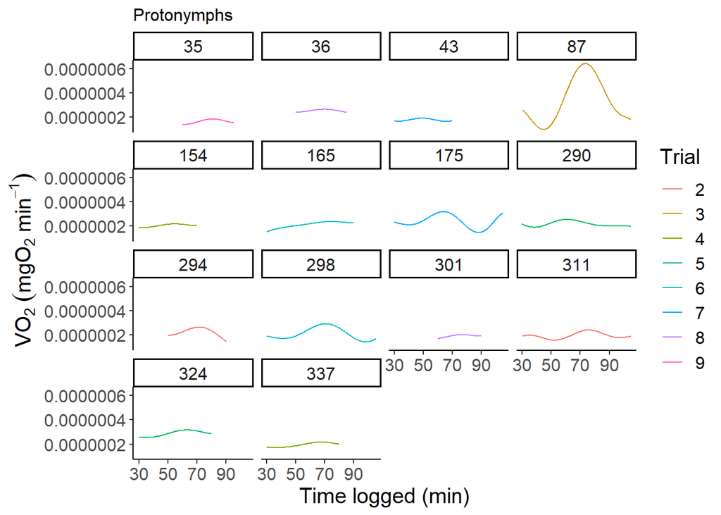

```r
protos <- derivs2%>%
  filter(stage=="Protonymph")


ggplot(protos, aes(x=logtime, y=first2,color=as.factor(trial)))+ #MODIFY FOR EACH TRIAL
  geom_line()+
  facet_wrap(~ind.x)+
  theme_classic()+
  theme(text = element_text(size = 15), plot.title = element_text(size = (12)))+
  xlab("Time logged (min)")+
  ylab(bquote(VO[2]~(mgO[2]~min^-1)))+
  ggtitle("Protonymphs")+
  labs(colour = "Trial")
```

```r
ggsave(plot=last_plot(),filename="DerivsTrace_ProtonymphsTrim.jpg",  path="Outputs/Derivative traces per stage/",width=7, height=7, units="in")
```

##### 9.2.3.2.2 Deutonymphs

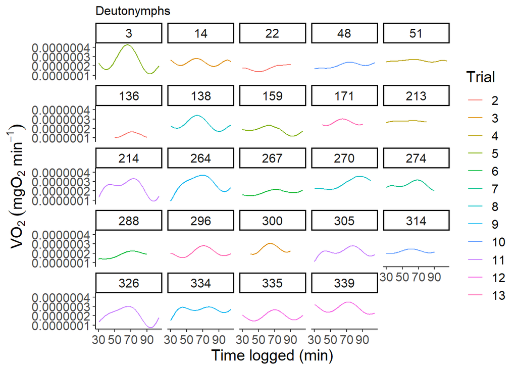

```r
deutos <- derivs2%>%
  filter(stage=="Deutonymph")


ggplot(deutos, aes(x=logtime, y=first2,color=as.factor(trial)))+ #MODIFY FOR EACH TRIAL
  geom_line()+
  facet_wrap(~ind.x)+
  theme_classic()+
  theme(text = element_text(size = 15), plot.title = element_text(size = (12)))+
  xlab("Time logged (min)")+
 ylab(bquote(VO[2]~(mgO[2]~min^-1)))+
  ggtitle("Deutonymphs")+
  labs(colour = "Trial")
```

```r
ggsave(plot=last_plot(),filename="DerivsnTrace_DeutonymphsTrim.jpg",  path="Outputs/Derivative traces per stage/",width=7, height=7, units="in")
```

##### 9.2.3.2.3 Tritonymphs

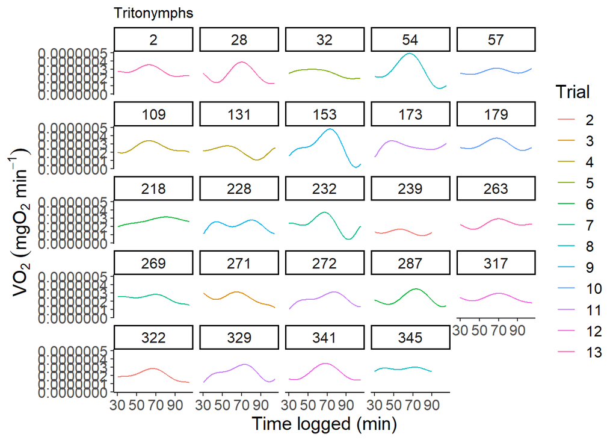

```r
Tritos <- derivs2%>%
  filter(stage=="Tritonymph")


ggplot(Tritos, aes(x=logtime, y=first2,color=as.factor(trial)))+ #MODIFY FOR EACH TRIAL
  geom_line()+
  facet_wrap(~ind.x)+
  theme_classic()+
  theme(text = element_text(size = 15), plot.title = element_text(size = (12)))+
  xlab("Time logged (min)")+
  ylab(bquote(VO[2]~(mgO[2]~min^-1)))+
  ggtitle("Tritonymphs")+
  labs(colour = "Trial")
```

```r
ggsave(plot=last_plot(),filename="DerivsTrace_TritonymphsTrim.jpg",  path="Outputs/Derivative traces per stage/", width=7, height=7, units="in")
```

##### 9.2.3.2.4 Males

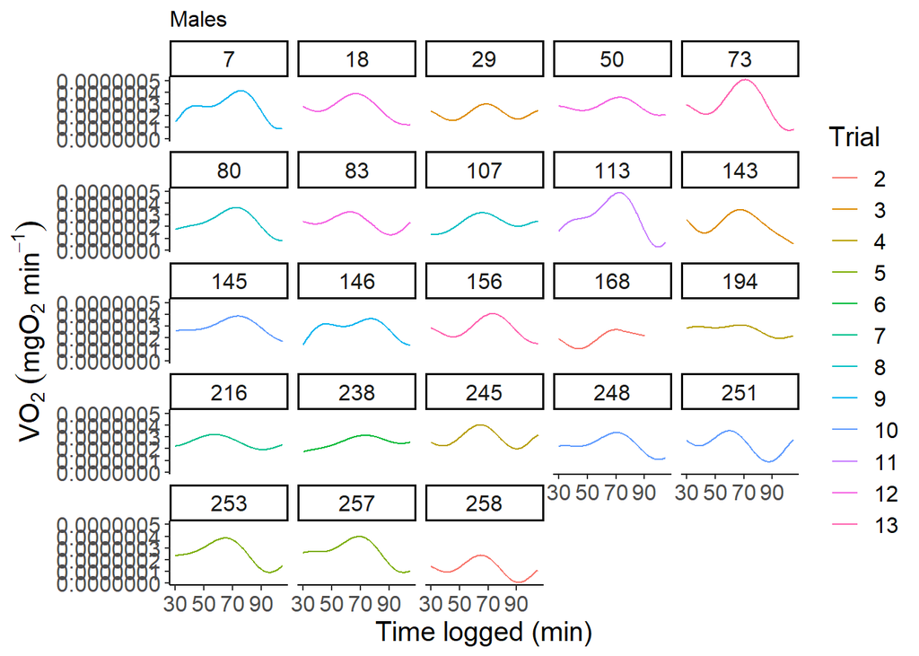

```r
males <- derivs2%>%
  filter(stage=="Male")


ggplot(males, aes(x=logtime, y=first2,color=as.factor(trial)))+ #MODIFY FOR EACH TRIAL
  geom_line()+
  facet_wrap(~ind.x)+
  theme_classic()+
  theme(text = element_text(size = 15), plot.title = element_text(size = (12)))+
  xlab("Time logged (min)")+
  ylab(bquote(VO[2]~(mgO[2]~min^-1)))+
  ggtitle("Males")+
  labs(colour = "Trial")
```

```r
ggsave(plot=last_plot(),filename="DerivsTrace_MalesTrim.jpg",  path="Outputs/Derivative traces per stage/",width=7, height=7, units="in")
```

##### 9.2.3.2.5 Females

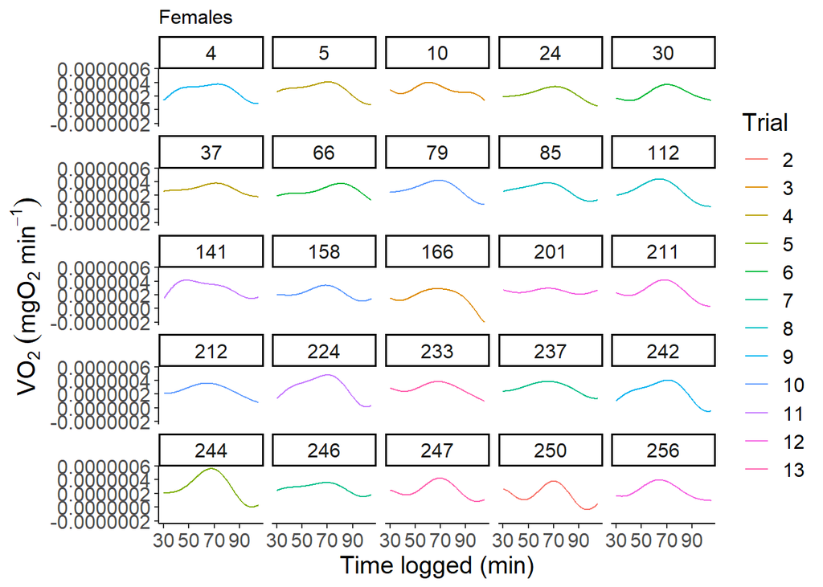

```r
females <- derivs2%>%
  filter(stage=="Female")


ggplot(females, aes(x=logtime, y=first2,color=as.factor(trial)))+ #MODIFY FOR EACH TRIAL
  geom_line()+
  facet_wrap(~ind.x)+
  theme_classic()+
  theme(text = element_text(size = 15), plot.title = element_text(size = (12)))+
  xlab("Time logged (min)")+
 ylab(bquote(VO[2]~(mgO[2]~min^-1)))+
  ggtitle("Females")+
  labs(colour = "Trial")
```

```r
ggsave(plot=last_plot(),filename="DerivsTrace_FemalesTrim.jpg",  path="Outputs/Derivative traces per stage/",width=7, height=7, units="in")
```

# 10 Estimating final values of physiological tolerance

## 10.1 Getting the maximum rate of oxygen consumption (Rate optima, Ropt)

> As we did before, we can now estimate the point in time where the rate of oxygen consumed was maximized (which represents the Rate optima, Ropt) for the newly trimmed traces.

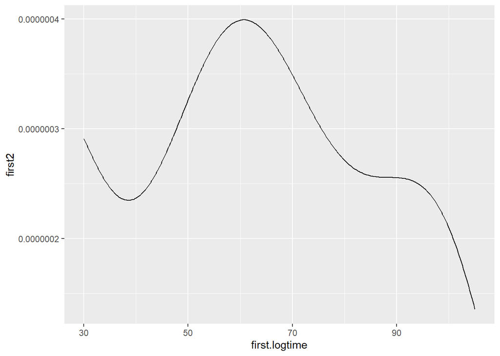

```r
derivs<-read.csv("Outputs/derivs_manualtrimforsome.csv") #getting the derivative data


derivs<-derivs %>%
  mutate(first2=first.y1*-1)%>% #Converting the slopes to positive
  filter(between(first.logtime, 30, 105)) #Triming the timeframe to the actual slope time

# Plotting to see if the conversion looks right
derivs%>%
  filter(id==10) %>%
  ggplot(aes(x=first.logtime, y=first2))+geom_line()
```

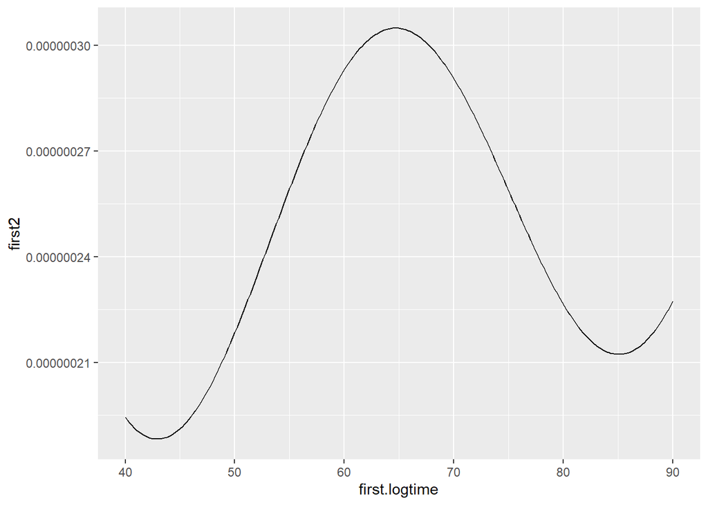

```r
derivs%>%
  filter(id==300) %>%
  ggplot(aes(x=first.logtime, y=first2))+geom_line()
```

```r
# Getting the row with the maximum value for each individual
ropt<-derivs %>%
     group_by(id) %>%
     slice(which.max(first2))%>% #selects the row where the amximum point is recorded for each individual
  mutate(logtime=first.logtime, #changes the names of logtime and individual to facilitate merging in the next steps
         ind=id)
```

## 10.2 Getting the Temperature optima (Topt)

> Once we know the point in time where the rate was maximize (Ropt), we can look for the temperature associated to that point in time during each trial, for each individual. We can do this by merging the ropt dataframe with the dataframe containing the temperature at each point in time (oxall).

> Here we create the file “ToptandRopts_trim.csv” with the Ropt and Top for all individuals estimated the same way. However, we still need to see if the data makes sense.

```r
#Merging the temperatures
topt<-difference_left_join(ropt,oxall, by=c("ind","logtime"), max_dist=0.13) %>% #Merges dataframes based on the closest logtime value (within 0.13). Since the ropt value coms from the derivatives, and the derivatives were estimated based on a sequence of values created for them rather than the real logtime values, the logtime in both dataframes is not exactly the same and we have to use an approximation instead
  group_by(ind.x, logtime.x, first.y1, first2) %>%
  summarize(tempcorr2=mean(tempcorr)) %>% #averaging the tempcorr for when multiple cells are called
  ungroup()


#getting the other demographic data
toptfinal<-oxall %>%
  select(c("date", "trial", "channel", "ind", "stage", "weight", "ramp")) %>% #selecting the more relevant variables
  group_by(ind)%>% #Grouping by individual
  filter(row_number()==1) %>% #getting just the first row for each individual
  right_join(topt, by=c("ind"="ind.x")) %>% #mergint the dataframes
  rename(logtime=logtime.x, #renaming some variables for simplification
         tempcorr=tempcorr2,
         ropt1=first.y1,
         ropt2=first2) %>%
  ungroup()%>%
  mutate(stage=fct_relevel(stage, "Protonymph", "Deutonymph", "Tritonymph",  "Male", "Female")) #changing the order of the levels within the factor "stage"

levels(toptfinal$stage)
```

```
## [1] "Protonymph" "Deutonymph" "Tritonymph" "Male"       "Female"
```

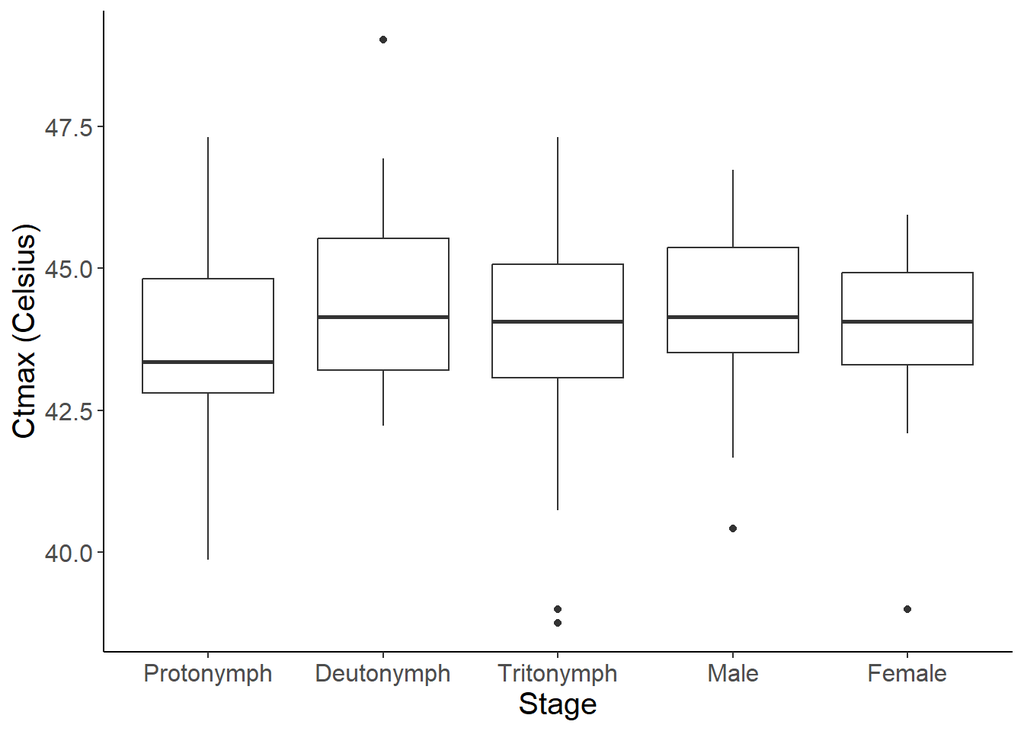

```r
#Visualizing the topt and Ropt

## Temperature optima
ggplot(toptfinal, aes(x=stage, y=tempcorr))+geom_boxplot() +theme_classic() +
  theme(text = element_text(size = 15))+
  xlab("Stage")+
  ylab("Ctmax (Celsius)")
```

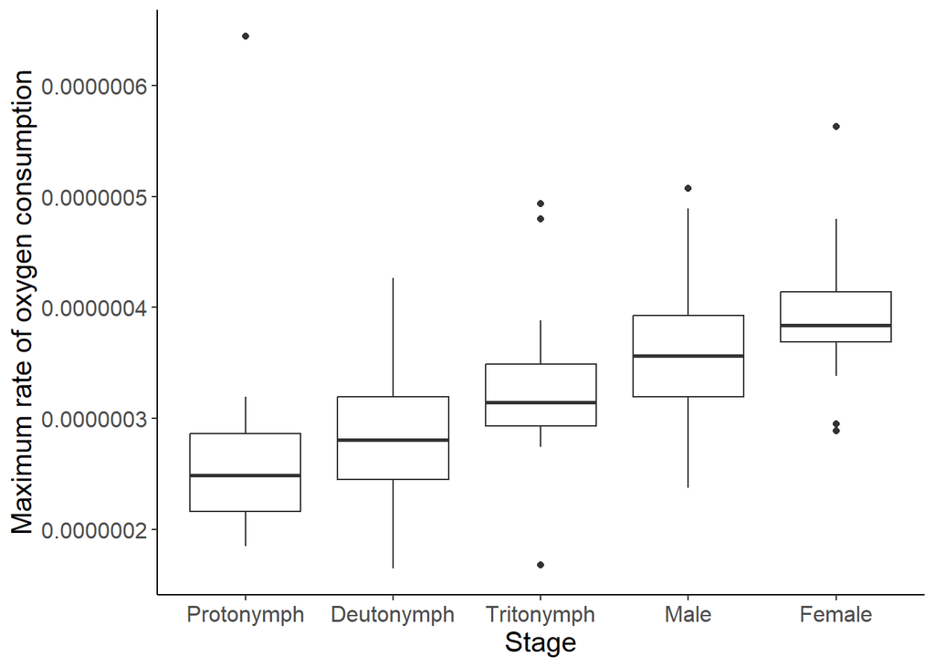

```r
#Rate optima
ggplot(toptfinal, aes(x=stage, y=ropt2))+geom_boxplot() +theme_classic() +
  theme(text = element_text(size = 15))+
  xlab("Stage")+
  ylab("Maximum rate of oxygen consumption")
```

```r
#Saving the file
write.csv(toptfinal, "Outputs/ToptandRopts_trim.csv")
```

### 10.2.1 Evaluating extreme points for topt and ropt

> This would help me see if there are any weird trends with the data. I dropped trial 2 because the ramping rate on it was lower than that of the other trials and was biasing the results

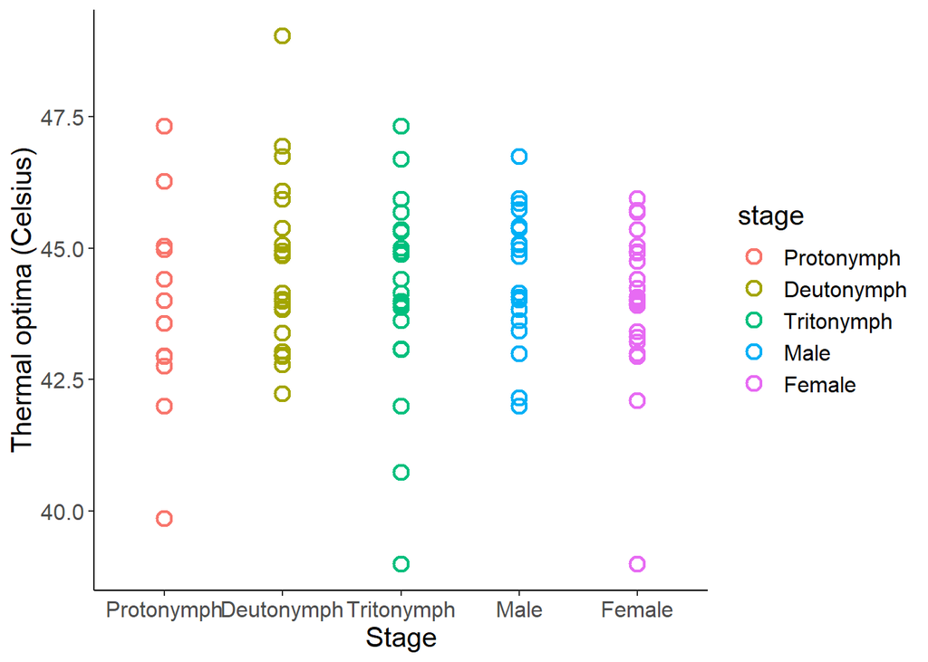

```r
# Plot with prediction trends, standard error and data
dat<-read.csv("Outputs/ToptandRopts_trim.csv")
dat<-dat%>%
  mutate(stage=fct_relevel(stage, "Protonymph", "Deutonymph", "Tritonymph",  "Male","Female")) %>%
  arrange(stage)
dat2<-dat%>%filter(trial!=2)

plot<-ggplot(dat2, aes(x = stage))+
  geom_point(aes(y = tempcorr, color=stage), size = 3, shape=1, stroke=1.2) +
  theme_classic()+ theme(text = element_text(size = 15))+
  xlab("Stage")+
  ylab("Thermal optima (Celsius)")
plot
```

```r
# Plotting with averages
averages<-dat2%>%
  group_by(stage) %>%
  summarize(mean=mean(tempcorr), sd=sd(tempcorr), n=n(), sem=sd/sqrt(n))
averages
```

| stage | mean | sd | n | sem |
| --- | --- | --- | --- | --- |
| Protonymph | 43.83595 | 1.980445 | 12 | 0.5717053 |
| Deutonymph | 44.54218 | 1.657489 | 22 | 0.3533778 |
| Tritonymph | 44.13545 | 1.856658 | 22 | 0.3958408 |
| Male | 44.50298 | 1.247730 | 21 | 0.2722771 |
| Female | 44.07966 | 1.486722 | 24 | 0.3034759 |

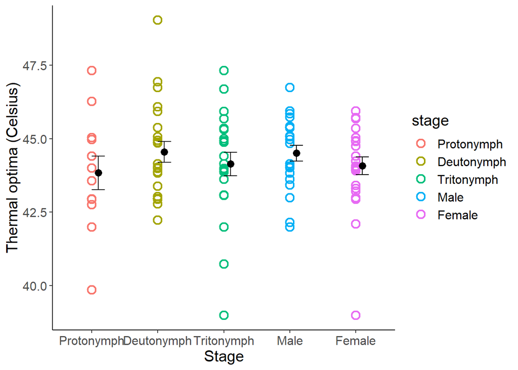

```r
averages$lwr3 <- with(averages, mean -  sem) #Using just the standard error
averages$upr3 <- with(averages, mean + sem)


# Plot with prediction trends, standard error and data
plot<-ggplot(dat2, aes(x = stage))+
  geom_point(aes(y = tempcorr, color=stage), size = 3, shape=1, stroke=1.2)  +
  geom_point(aes(y = mean, color=stage),color = "black", size = 3, data = averages, position=position_nudge(x=0.1)) +
  geom_errorbar(aes(x=stage, ymin = lwr3, ymax = upr3, group=stage), color = "black", data = averages, inherit.aes = FALSE, position=position_nudge(x=0.1), width=0.2) +
  theme_classic()+ theme(text = element_text(size = 15))+
  xlab("Stage")+
  ylab("Thermal optima (Celsius)")
plot
```

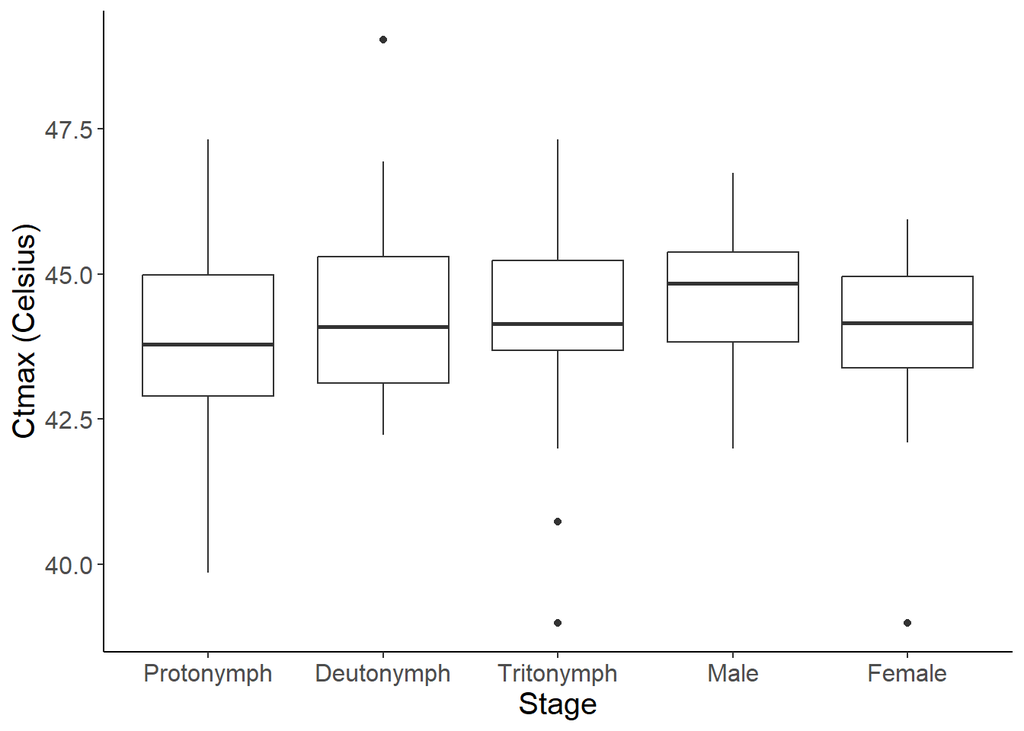

```r
## Checking outliers
ggplot(dat2, aes(x=stage, y=tempcorr))+geom_boxplot() +theme_classic() +
  theme(text = element_text(size = 15))+
  xlab("Stage")+
  ylab("Ctmax (Celsius)")
```

```r
#Taking out possible outliers (based on boxplot)
#dat3<-dat2 %>%
#  filter(!ind %in% c(35,32,173,141,270))

dat3<-dat2 %>%
  filter(!ind %in% c(270, 239, 173,141,35))


# Plotting with averages
averages<-dat3%>%
  group_by(stage) %>%
  summarize(mean=mean(tempcorr), sd=sd(tempcorr), n=n(), sem=sd/sqrt(n))
averages
```

| stage | mean | sd | n | sem |
| --- | --- | --- | --- | --- |
| Protonymph | 43.51981 | 1.730641 | 11 | 0.5218078 |
| Deutonymph | 44.32860 | 1.353110 | 21 | 0.2952729 |
| Tritonymph | 44.38065 | 1.493563 | 21 | 0.3259222 |
| Male | 44.50298 | 1.247730 | 21 | 0.2722771 |
| Female | 44.30111 | 1.039403 | 23 | 0.2167305 |

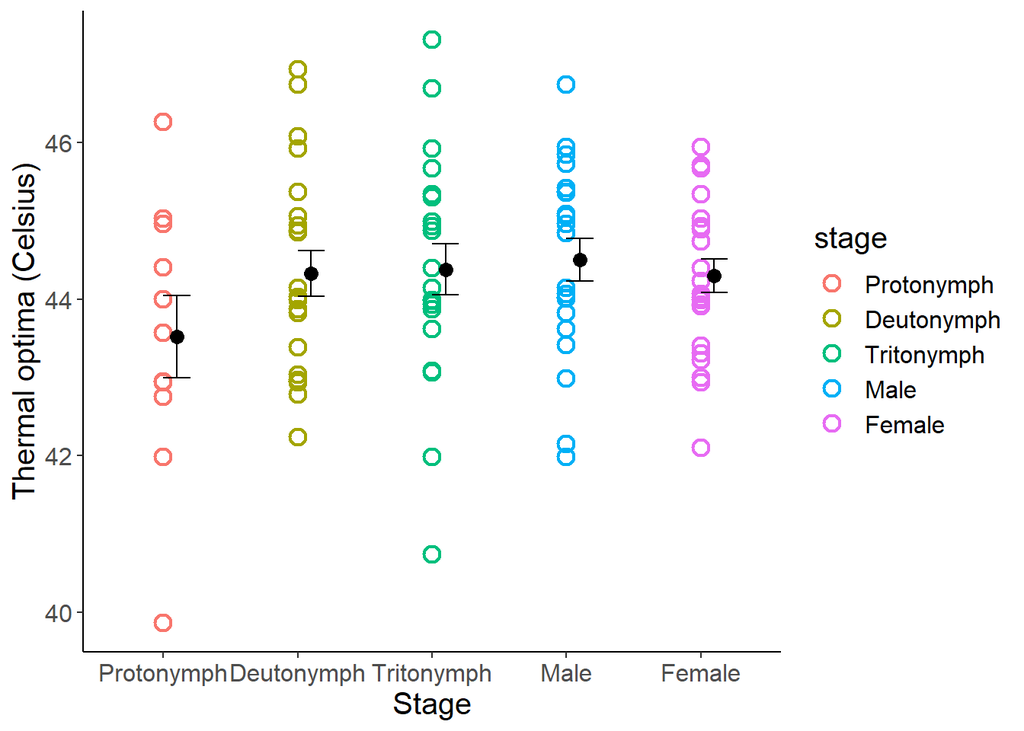

```r
averages$lwr3 <- with(averages, mean -  sem) #Using just the standard error
averages$upr3 <- with(averages, mean + sem)


# Plot with prediction trends, standard error and data
plot<-ggplot(dat3, aes(x = stage))+
  geom_point(aes(y = tempcorr, color=stage), size = 3, shape=1, stroke=1.2)  +
  geom_point(aes(y = mean, color=stage),color = "black", size = 3, data = averages, position=position_nudge(x=0.1)) +
  geom_errorbar(aes(x=stage, ymin = lwr3, ymax = upr3, group=stage), color = "black", data = averages, inherit.aes = FALSE, position=position_nudge(x=0.1), width=0.2) +   theme_classic()+ theme(text = element_text(size = 15))+
  xlab("Stage")+
  ylab("Thermal optima (Celsius)")
plot
```

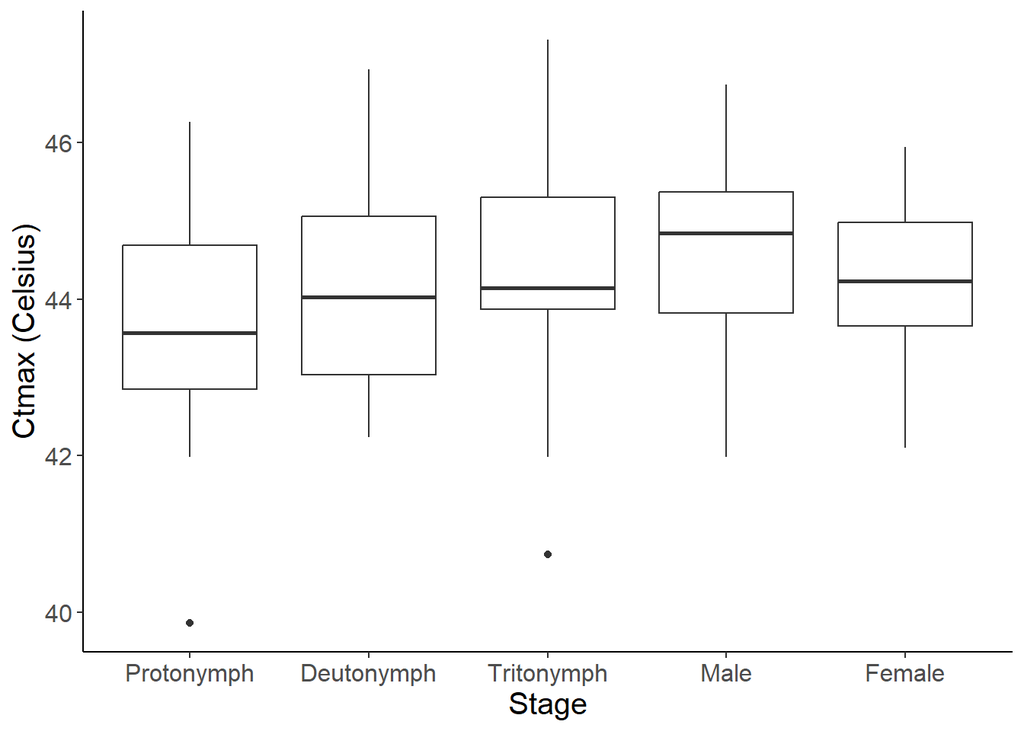

```r
## Checking outliers
ggplot(dat3, aes(x=stage, y=tempcorr))+geom_boxplot() +theme_classic() +
  theme(text = element_text(size = 15))+
  xlab("Stage")+
  ylab("Ctmax (Celsius)")
```

### 10.2.2 Comparing the Ropt with the inflection points

> To see how close we got the point from the original dataset of the second derivative.

```r
inflec<-read.csv("Outputs/inflections.csv")

inflec2<-inflec %>%
  select(id, real, values, rounded) %>%
  rename(ind=id,
         logtime=real)

dat<-read.csv("Outputs/ToptandRopts_trim.csv")

derivsinf<-difference_left_join(dat,inflec2, by=c("ind","logtime"), max_dist=0.13) #Merges dataframes based on the closest logtime value (within 0.13)

derivsinf<-derivsinf %>%
  mutate(diff=round(logtime.x-logtime.y, digits=3))
```

> All the Ropts chose where indeed, very close (less than 0.1 difference) to an inflection point

## 10.3 Getting the activation energy

> The activation energy is how much energy it took the inviduals to reach the Ropt. We can get it by following the procedure described by Brown et al. (2004), which is a modification of the Arrhenius equation.

For this I need to do the following to each individual: 1. Trim the first derivative from the closests left-sided minimum to the maximum value 2. Join the logtime from the trimmed derivative in 1, to the portion of temps associated on oxall 3. convert the temps to Kelvin, multiply it by the Boltzmann constant and convert it to electron voltz. Then do the inversion(1/x) 4. Log transform (ln) the derivate 5. Get the slope of 4 as predicted by 3 (ln(deriv)~temperature) 6. Save such slope in a dataframe 7. Put everything in a single dataframe 8. Associate demographic data to each id

### 10.3.1 Trimming the first derivative for each individual

> Here, I manually select the first part of the slope that leads to the Ropt, just to get some range closer for the final function below

```r
# Creating dataframe of manually cropped trends first
derivs<-read.csv("Outputs/derivs_manualtrimforsome.csv") #getting the derivative data


derivs<-derivs %>%
  mutate(first2=first.y1*-1)%>% #Converting the slopes to positive
  filter(between(first.logtime, 30, 105))

## Trim the first derivative from the closests left-sided minimum to the maximum value

derivstrim<-derivs%>%
  filter(id=="2") %>% #filtering to each individual
  filter(between(first.logtime, 35, 65)) # %>% #Triming the timeframe to the approximate relevant times (based on plot)

indiv<-derivs%>%
  filter(id=="3") %>% #filtering to each individual
  filter(between(first.logtime, 35, 66)) # %>% #Triming the timeframe to the approximate relevant times (based on plot)
derivstrim<- bind_rows(derivstrim, indiv)

indiv<-derivs%>%
  filter(id=="4") %>% #filtering to each individual
  filter(between(first.logtime, 40, 80)) # %>% #Triming the timeframe to the approximate relevant times (based on plot)
derivstrim<- bind_rows(derivstrim, indiv)

indiv<-derivs%>%
  filter(id=="5") %>% #filtering to each individual
  filter(between(first.logtime, 40, 75)) # %>% #Triming the timeframe to the approximate relevant times (based on plot)
derivstrim<- bind_rows(derivstrim, indiv)

indiv<-derivs%>%
  filter(id=="7") %>% #filtering to each individual
  filter(between(first.logtime, 50, 80)) # %>% #Triming the timeframe to the approximate relevant times (based on plot)
derivstrim<- bind_rows(derivstrim, indiv)

indiv<-derivs%>%
  filter(id=="10") %>% #filtering to each individual
  filter(between(first.logtime, 35, 70)) # %>% #Triming the timeframe to the approximate relevant times (based on plot)
derivstrim<- bind_rows(derivstrim, indiv)

indiv<-derivs%>%
  filter(id=="14") %>% #filtering to each individual
  filter(between(first.logtime, 35, 70)) # %>% #Triming the timeframe to the approximate relevant times (based on plot)
derivstrim<- bind_rows(derivstrim, indiv)

indiv<-derivs%>%
  filter(id=="18") %>% #filtering to each individual
  filter(between(first.logtime, 35, 80)) # %>% #Triming the timeframe to the approximate relevant times (based on plot)
derivstrim<- bind_rows(derivstrim, indiv)

indiv<-derivs%>%
  filter(id=="22") %>% #filtering to each individual
  filter(between(first.logtime, 40, 90)) # %>% #Triming the timeframe to the approximate relevant times (based on plot)
derivstrim<- bind_rows(derivstrim, indiv)

indiv<-derivs%>%
  filter(id=="24") %>% #filtering to each individual
  filter(between(first.logtime, 40, 80)) # %>% #Triming the timeframe to the approximate relevant times (based on plot)
derivstrim<- bind_rows(derivstrim, indiv)

indiv<-derivs%>%
  filter(id=="28") %>% #filtering to each individual
  filter(between(first.logtime, 40, 90)) # %>% #Triming the timeframe to the approximate relevant times (based on plot)
derivstrim<- bind_rows(derivstrim, indiv)

indiv<-derivs%>%
  filter(id=="29") %>% #filtering to each individual
  filter(between(first.logtime, 40, 70)) # %>% #Triming the timeframe to the approximate relevant times (based on plot)
derivstrim<- bind_rows(derivstrim, indiv)

indiv<-derivs%>%
  filter(id=="30") %>% #filtering to each individual
  filter(between(first.logtime, 40, 80)) # %>% #Triming the timeframe to the approximate relevant times (based on plot)
derivstrim<- bind_rows(derivstrim, indiv)

indiv<-derivs%>%
  filter(id=="32") %>% #filtering to each individual
  filter(between(first.logtime, 20, 70)) # %>% #Triming the timeframe to the approximate relevant times (based on plot)
derivstrim<- bind_rows(derivstrim, indiv)

indiv<-derivs%>%
  filter(id=="35") %>% #filtering to each individual
  filter(between(first.logtime, 60, 82)) # %>% #Triming the timeframe to the approximate relevant times (based on plot)
derivstrim<- bind_rows(derivstrim, indiv)

indiv<-derivs%>%
  filter(id=="36") %>% #filtering to each individual
  filter(between(first.logtime, 50, 80)) # %>% #Triming the timeframe to the approximate relevant times (based on plot)
derivstrim<- bind_rows(derivstrim, indiv)

indiv<-derivs%>%
  filter(id=="37") %>% #filtering to each individual
  filter(between(first.logtime, 40, 80)) # %>% #Triming the timeframe to the approximate relevant times (based on plot)
derivstrim<- bind_rows(derivstrim, indiv)

#Changed
indiv<-derivs%>%
  filter(id=="43") %>% #filtering to each individual
  filter(between(first.logtime, 30, 55)) # %>% #Triming the timeframe to the approximate relevant times (based on plot)
derivstrim<- bind_rows(derivstrim, indiv)

indiv<-derivs%>%
  filter(id=="48") %>% #filtering to each individual
  filter(between(first.logtime, 50, 80)) # %>% #Triming the timeframe to the approximate relevant times (based on plot)
derivstrim<- bind_rows(derivstrim, indiv)

indiv<-derivs%>%
  filter(id=="50") %>% #filtering to each individual
  filter(between(first.logtime, 40, 80)) # %>% #Triming the timeframe to the approximate relevant times (based on plot)
derivstrim<- bind_rows(derivstrim, indiv)

indiv<-derivs%>%
  filter(id=="54") %>% #filtering to each individual
  filter(between(first.logtime, 40, 70)) # %>% #Triming the timeframe to the approximate relevant times (based on plot)
derivstrim<- bind_rows(derivstrim, indiv)

indiv<-derivs%>%
  filter(id=="57") %>% #filtering to each individual
  filter(between(first.logtime, 40, 70)) # %>% #Triming the timeframe to the approximate relevant times (based on plot)
derivstrim<- bind_rows(derivstrim, indiv)

indiv<-derivs%>%
  filter(id=="66") %>% #filtering to each individual
  filter(between(first.logtime, 50, 90)) # %>% #Triming the timeframe to the approximate relevant times (based on plot)
derivstrim<- bind_rows(derivstrim, indiv)

indiv<-derivs%>%
  filter(id=="73") %>% #filtering to each individual
  filter(between(first.logtime, 40, 80)) # %>% #Triming the timeframe to the approximate relevant times (based on plot)
derivstrim<- bind_rows(derivstrim, indiv)

indiv<-derivs%>%
  filter(id=="79") %>% #filtering to each individual
  filter(between(first.logtime, 40, 80)) # %>% #Triming the timeframe to the approximate relevant times (based on plot)
derivstrim<- bind_rows(derivstrim, indiv)
```

```r
indiv<-derivs%>%
  filter(id=="80") %>% #filtering to each individual
  filter(between(first.logtime, 40, 80)) # %>% #Triming the timeframe to the approximate relevant times (based on plot)
derivstrim<- bind_rows(derivstrim, indiv)

indiv<-derivs%>%
  filter(id=="83") %>% #filtering to each individual
  filter(between(first.logtime, 30, 70)) # %>% #Triming the timeframe to the approximate relevant times (based on plot)
derivstrim<- bind_rows(derivstrim, indiv)

indiv<-derivs%>%
  filter(id=="85") %>% #filtering to each individual
  filter(between(first.logtime, 30, 75)) # %>% #Triming the timeframe to the approximate relevant times (based on plot)
derivstrim<- bind_rows(derivstrim, indiv)

indiv<-derivs%>%
  filter(id=="87") %>% #filtering to each individual
  filter(between(first.logtime, 40, 80)) # %>% #Triming the timeframe to the approximate relevant times (based on plot)
derivstrim<- bind_rows(derivstrim, indiv)

indiv<-derivs%>%
  filter(id=="107") %>% #filtering to each individual
  filter(between(first.logtime, 40, 70)) # %>% #Triming the timeframe to the approximate relevant times (based on plot)
derivstrim<- bind_rows(derivstrim, indiv)

indiv<-derivs%>%
  filter(id=="109") %>% #filtering to each individual
  filter(between(first.logtime, 30, 70)) # %>% #Triming the timeframe to the approximate relevant times (based on plot)
derivstrim<- bind_rows(derivstrim, indiv)

indiv<-derivs%>%
  filter(id=="112") %>% #filtering to each individual
  filter(between(first.logtime, 30, 70)) # %>% #Triming the timeframe to the approximate relevant times (based on plot)
derivstrim<- bind_rows(derivstrim, indiv)

indiv<-derivs%>%
  filter(id=="113") %>% #filtering to each individual
  filter(between(first.logtime, 45, 80)) # %>% #Triming the timeframe to the approximate relevant times (based on plot)
derivstrim<- bind_rows(derivstrim, indiv)

indiv<-derivs%>%
  filter(id=="131") %>% #filtering to each individual
  filter(between(first.logtime, 30, 65)) # %>% #Triming the timeframe to the approximate relevant times (based on plot)
derivstrim<- bind_rows(derivstrim, indiv)

indiv<-derivs%>%
  filter(id=="136") %>% #filtering to each individual
  filter(between(first.logtime, 50, 74)) # %>% #Triming the timeframe to the approximate relevant times (based on plot)
derivstrim<- bind_rows(derivstrim, indiv)

indiv<-derivs%>%
  filter(id=="138") %>% #filtering to each individual
  filter(between(first.logtime, 40, 70)) # %>% #Triming the timeframe to the approximate relevant times (based on plot)
derivstrim<- bind_rows(derivstrim, indiv)

indiv<-derivs%>%
  filter(id=="143") %>% #filtering to each individual
  filter(between(first.logtime, 40, 80)) # %>% #Triming the timeframe to the approximate relevant times (based on plot)
derivstrim<- bind_rows(derivstrim, indiv)

indiv<-derivs%>%
  filter(id=="145") %>% #filtering to each individual
  filter(between(first.logtime, 40, 80)) # %>% #Triming the timeframe to the approximate relevant times (based on plot)
derivstrim<- bind_rows(derivstrim, indiv)

indiv<-derivs%>%
  filter(id=="146") %>% #filtering to each individual
  filter(between(first.logtime, 50, 80)) # %>% #Triming the timeframe to the approximate relevant times (based on plot)
derivstrim<- bind_rows(derivstrim, indiv)

indiv<-derivs%>%
  filter(id=="153") %>% #filtering to each individual
  filter(between(first.logtime, 50, 80)) # %>% #Triming the timeframe to the approximate relevant times (based on plot)
derivstrim<- bind_rows(derivstrim, indiv)

#Changed
indiv<-derivs%>%
  filter(id=="154") %>% #filtering to each individual
  filter(between(first.logtime, 30,65)) # %>% #Triming the timeframe to the approximate relevant times (based on plot)
derivstrim<- bind_rows(derivstrim, indiv)

indiv<-derivs%>%
  filter(id=="156") %>% #filtering to each individual
  filter(between(first.logtime, 40, 80)) # %>% #Triming the timeframe to the approximate relevant times (based on plot)
derivstrim<- bind_rows(derivstrim, indiv)

indiv<-derivs%>%
  filter(id=="158") %>% #filtering to each individual
  filter(between(first.logtime, 40, 70)) # %>% #Triming the timeframe to the approximate relevant times (based on plot)
derivstrim<- bind_rows(derivstrim, indiv)

indiv<-derivs%>%
  filter(id=="159") %>% #filtering to each individual
  filter(between(first.logtime, 40, 70)) # %>% #Triming the timeframe to the approximate relevant times (based on plot)
derivstrim<- bind_rows(derivstrim, indiv)

indiv<-derivs%>%
  filter(id=="165") %>% #filtering to each individual
  filter(between(first.logtime, 30, 90)) # %>% #Triming the timeframe to the approximate relevant times (based on plot)
derivstrim<- bind_rows(derivstrim, indiv)

indiv<-derivs%>%
  filter(id=="166") %>% #filtering to each individual
  filter(between(first.logtime, 35, 80)) # %>% #Triming the timeframe to the approximate relevant times (based on plot)
derivstrim<- bind_rows(derivstrim, indiv)

indiv<-derivs%>%
  filter(id=="168") %>% #filtering to each individual
  filter(between(first.logtime, 40, 80)) # %>% #Triming the timeframe to the approximate relevant times (based on plot)
derivstrim<- bind_rows(derivstrim, indiv)

indiv<-derivs%>%
  filter(id=="171") %>% #filtering to each individual
  filter(between(first.logtime, 40, 70)) # %>% #Triming the timeframe to the approximate relevant times (based on plot)
derivstrim<- bind_rows(derivstrim, indiv)

indiv<-derivs%>%
  filter(id=="175") %>% #filtering to each individual
  filter(between(first.logtime, 40, 70)) # %>% #Triming the timeframe to the approximate relevant times (based on plot)
derivstrim<- bind_rows(derivstrim, indiv)

indiv<-derivs%>%
  filter(id=="179") %>% #filtering to each individual
  filter(between(first.logtime, 40, 70)) # %>% #Triming the timeframe to the approximate relevant times (based on plot)
derivstrim<- bind_rows(derivstrim, indiv)

indiv<-derivs%>%
  filter(id=="194") %>% #filtering to each individual
  filter(between(first.logtime, 50, 70)) # %>% #Triming the timeframe to the approximate relevant times (based on plot)
derivstrim<- bind_rows(derivstrim, indiv)
```

```r
indiv<-derivs%>%
  filter(id=="201") %>% #filtering to each individual
  filter(between(first.logtime, 40, 70)) # %>% #Triming the timeframe to the approximate relevant times (based on plot)
derivstrim<- bind_rows(derivstrim, indiv)

indiv<-derivs%>%
  filter(id=="211") %>% #filtering to each individual
  filter(between(first.logtime, 35, 75)) # %>% #Triming the timeframe to the approximate relevant times (based on plot)
derivstrim<- bind_rows(derivstrim, indiv)

indiv<-derivs%>%
  filter(id=="212") %>% #filtering to each individual
  filter(between(first.logtime, 30, 70)) # %>% #Triming the timeframe to the approximate relevant times (based on plot)
derivstrim<- bind_rows(derivstrim, indiv)

indiv<-derivs%>%
  filter(id=="214") %>% #filtering to each individual
  filter(between(first.logtime, 50, 80)) # %>% #Triming the timeframe to the approximate relevant times (based on plot)
derivstrim<- bind_rows(derivstrim, indiv)

indiv<-derivs%>%
  filter(id=="216") %>% #filtering to each individual
  filter(between(first.logtime, 30, 60)) # %>% #Triming the timeframe to the approximate relevant times (based on plot)
derivstrim<- bind_rows(derivstrim, indiv)

indiv<-derivs%>%
  filter(id=="218") %>% #filtering to each individual
  filter(between(first.logtime, 20, 81)) # %>% #Triming the timeframe to the approximate relevant times (based on plot)
derivstrim<- bind_rows(derivstrim, indiv)

indiv<-derivs%>%
  filter(id=="224") %>% #filtering to each individual
  filter(between(first.logtime, 40, 80)) # %>% #Triming the timeframe to the approximate relevant times (based on plot)
derivstrim<- bind_rows(derivstrim, indiv)

indiv<-derivs%>%
  filter(id=="228") %>% #filtering to each individual
  filter(between(first.logtime, 60, 81)) # %>% #Triming the timeframe to the approximate relevant times (based on plot)
derivstrim<- bind_rows(derivstrim, indiv)

indiv<-derivs%>%
  filter(id=="232") %>% #filtering to each individual
  filter(between(first.logtime, 40, 70)) # %>% #Triming the timeframe to the approximate relevant times (based on plot)
derivstrim<- bind_rows(derivstrim, indiv)

indiv<-derivs%>%
  filter(id=="233") %>% #filtering to each individual
  filter(between(first.logtime, 40, 70)) # %>% #Triming the timeframe to the approximate relevant times (based on plot)
derivstrim<- bind_rows(derivstrim, indiv)

indiv<-derivs%>%
  filter(id=="237") %>% #filtering to each individual
  filter(between(first.logtime, 30, 70)) # %>% #Triming the timeframe to the approximate relevant times (based on plot)
derivstrim<- bind_rows(derivstrim, indiv)

indiv<-derivs%>%
  filter(id=="238") %>% #filtering to each individual
  filter(between(first.logtime, 20, 80)) # %>% #Triming the timeframe to the approximate relevant times (based on plot)
derivstrim<- bind_rows(derivstrim, indiv)

indiv<-derivs%>%
  filter(id=="239") %>% #filtering to each individual
  filter(between(first.logtime, 30, 60)) # %>% #Triming the timeframe to the approximate relevant times (based on plot)
derivstrim<- bind_rows(derivstrim, indiv)

indiv<-derivs%>%
  filter(id=="242") %>% #filtering to each individual
  filter(between(first.logtime, 40, 80)) # %>% #Triming the timeframe to the approximate relevant times (based on plot)
derivstrim<- bind_rows(derivstrim, indiv)

indiv<-derivs%>%
  filter(id=="244") %>% #filtering to each individual
  filter(between(first.logtime, 40, 80)) # %>% #Triming the timeframe to the approximate relevant times (based on plot)
derivstrim<- bind_rows(derivstrim, indiv)

indiv<-derivs%>%
  filter(id=="245") %>% #filtering to each individual
  filter(between(first.logtime, 20, 70)) # %>% #Triming the timeframe to the approximate relevant times (based on plot)
derivstrim<- bind_rows(derivstrim, indiv)

indiv<-derivs%>%
  filter(id=="246") %>% #filtering to each individual
  filter(between(first.logtime, 40, 75)) # %>% #Triming the timeframe to the approximate relevant times (based on plot)
derivstrim<- bind_rows(derivstrim, indiv)

indiv<-derivs%>%
  filter(id=="247") %>% #filtering to each individual
  filter(between(first.logtime, 40, 80)) # %>% #Triming the timeframe to the approximate relevant times (based on plot)
derivstrim<- bind_rows(derivstrim, indiv)

indiv<-derivs%>%
  filter(id=="248") %>% #filtering to each individual
  filter(between(first.logtime, 40, 75)) # %>% #Triming the timeframe to the approximate relevant times (based on plot)
derivstrim<- bind_rows(derivstrim, indiv)

indiv<-derivs%>%
  filter(id=="250") %>% #filtering to each individual
  filter(between(first.logtime, 40, 75)) # %>% #Triming the timeframe to the approximate relevant times (based on plot)
derivstrim<- bind_rows(derivstrim, indiv)

indiv<-derivs%>%
  filter(id=="251") %>% #filtering to each individual
  filter(between(first.logtime, 40, 60)) # %>% #Triming the timeframe to the approximate relevant times (based on plot)
derivstrim<- bind_rows(derivstrim, indiv)

indiv<-derivs%>%
  filter(id=="253") %>% #filtering to each individual
  filter(between(first.logtime, 40, 75)) # %>% #Triming the timeframe to the approximate relevant times (based on plot)
derivstrim<- bind_rows(derivstrim, indiv)

indiv<-derivs%>%
  filter(id=="256") %>% #filtering to each individual
  filter(between(first.logtime, 30, 70)) # %>% #Triming the timeframe to the approximate relevant times (based on plot)
derivstrim<- bind_rows(derivstrim, indiv)

indiv<-derivs%>%
  filter(id=="257") %>% #filtering to each individual
  filter(between(first.logtime, 40, 80)) # %>% #Triming the timeframe to the approximate relevant times (based on plot)
derivstrim<- bind_rows(derivstrim, indiv)

indiv<-derivs%>%
  filter(id=="258") %>% #filtering to each individual
  filter(between(first.logtime, 40, 75)) # %>% #Triming the timeframe to the approximate relevant times (based on plot)
derivstrim<- bind_rows(derivstrim, indiv)

indiv<-derivs%>%
  filter(id=="263") %>% #filtering to each individual
  filter(between(first.logtime, 40, 70)) # %>% #Triming the timeframe to the approximate relevant times (based on plot)
derivstrim<- bind_rows(derivstrim, indiv)
```

```r
indiv<-derivs%>%
  filter(id=="264") %>% #filtering to each individual
  filter(between(first.logtime, 40, 75)) # %>% #Triming the timeframe to the approximate relevant times (based on plot)
derivstrim<- bind_rows(derivstrim, indiv)

indiv<-derivs%>%
  filter(id=="267") %>% #filtering to each individual
  filter(between(first.logtime, 40, 72)) # %>% #Triming the timeframe to the approximate relevant times (based on plot)
derivstrim<- bind_rows(derivstrim, indiv)

indiv<-derivs%>%
  filter(id=="269") %>% #filtering to each individual
  filter(between(first.logtime, 50, 75)) # %>% #Triming the timeframe to the approximate relevant times (based on plot)
derivstrim<- bind_rows(derivstrim, indiv)

indiv<-derivs%>%
  filter(id=="270") %>% #filtering to each individual
  filter(between(first.logtime, 45, 90)) # %>% #Triming the timeframe to the approximate relevant times (based on plot)
derivstrim<- bind_rows(derivstrim, indiv)

indiv<-derivs%>%
  filter(id=="271") %>% #filtering to each individual
  filter(between(first.logtime, 40, 70)) # %>% #Triming the timeframe to the approximate relevant times (based on plot)
derivstrim<- bind_rows(derivstrim, indiv)

indiv<-derivs%>%
  filter(id=="272") %>% #filtering to each individual
  filter(between(first.logtime, 50, 80)) # %>% #Triming the timeframe to the approximate relevant times (based on plot)
derivstrim<- bind_rows(derivstrim, indiv)

indiv<-derivs%>%
  filter(id=="274") %>% #filtering to each individual
  filter(between(first.logtime, 40, 75)) # %>% #Triming the timeframe to the approximate relevant times (based on plot)
derivstrim<- bind_rows(derivstrim, indiv)

indiv<-derivs%>%
  filter(id=="287") %>% #filtering to each individual
  filter(between(first.logtime, 40, 80)) # %>% #Triming the timeframe to the approximate relevant times (based on plot)
derivstrim<- bind_rows(derivstrim, indiv)

indiv<-derivs%>%
  filter(id=="288") %>% #filtering to each individual
  filter(between(first.logtime, 40, 75)) # %>% #Triming the timeframe to the approximate relevant times (based on plot)
derivstrim<- bind_rows(derivstrim, indiv)

indiv<-derivs%>%
  filter(id=="290") %>% #filtering to each individual
  filter(between(first.logtime, 35, 65)) # %>% #Triming the timeframe to the approximate relevant times (based on plot)
derivstrim<- bind_rows(derivstrim, indiv)

indiv<-derivs%>%
  filter(id=="294") %>% #filtering to each individual
  filter(between(first.logtime, 50, 75)) # %>% #Triming the timeframe to the approximate relevant times (based on plot)
derivstrim<- bind_rows(derivstrim, indiv)

indiv<-derivs%>%
  filter(id=="296") %>% #filtering to each individual
  filter(between(first.logtime, 40, 72)) # %>% #Triming the timeframe to the approximate relevant times (based on plot)
derivstrim<- bind_rows(derivstrim, indiv)

indiv<-derivs%>%
  filter(id=="298") %>% #filtering to each individual
  filter(between(first.logtime, 40, 72)) # %>% #Triming the timeframe to the approximate relevant times (based on plot)
derivstrim<- bind_rows(derivstrim, indiv)

indiv<-derivs%>%
  filter(id=="300") %>% #filtering to each individual
  filter(between(first.logtime, 40, 70)) # %>% #Triming the timeframe to the approximate relevant times (based on plot)
derivstrim<- bind_rows(derivstrim, indiv)


indiv<-derivs%>%
  filter(id=="305") %>% #filtering to each individual
  filter(between(first.logtime, 60, 80)) # %>% #Triming the timeframe to the approximate relevant times (based on plot)
derivstrim<- bind_rows(derivstrim, indiv)


indiv<-derivs%>%
  filter(id=="311") %>% #filtering to each individual
  filter(between(first.logtime, 40, 80)) # %>% #Triming the timeframe to the approximate relevant times (based on plot)
derivstrim<- bind_rows(derivstrim, indiv)

indiv<-derivs%>%
  filter(id=="314") %>% #filtering to each individual
  filter(between(first.logtime, 30, 65)) # %>% #Triming the timeframe to the approximate relevant times (based on plot)
derivstrim<- bind_rows(derivstrim, indiv)

indiv<-derivs%>%
  filter(id=="317") %>% #filtering to each individual
  filter(between(first.logtime, 40, 80)) # %>% #Triming the timeframe to the approximate relevant times (based on plot)
derivstrim<- bind_rows(derivstrim, indiv)

indiv<-derivs%>%
  filter(id=="322") %>% #filtering to each individual
  filter(between(first.logtime, 40, 75)) # %>% #Triming the timeframe to the approximate relevant times (based on plot)
derivstrim<- bind_rows(derivstrim, indiv)

indiv<-derivs%>%
  filter(id=="324") %>% #filtering to each individual
  filter(between(first.logtime, 30, 65)) # %>% #Triming the timeframe to the approximate relevant times (based on plot)
derivstrim<- bind_rows(derivstrim, indiv)

indiv<-derivs%>%
  filter(id=="326") %>% #filtering to each individual
  filter(between(first.logtime, 40, 75)) # %>% #Triming the timeframe to the approximate relevant times (based on plot)
derivstrim<- bind_rows(derivstrim, indiv)

indiv<-derivs%>%
  filter(id=="329") %>% #filtering to each individual
  filter(between(first.logtime, 50, 80)) # %>% #Triming the timeframe to the approximate relevant times (based on plot)
derivstrim<- bind_rows(derivstrim, indiv)

indiv<-derivs%>%
  filter(id=="334") %>% #filtering to each individual
  filter(between(first.logtime, 60, 80)) # %>% #Triming the timeframe to the approximate relevant times (based on plot)
derivstrim<- bind_rows(derivstrim, indiv)

indiv<-derivs%>%
  filter(id=="335") %>% #filtering to each individual
  filter(between(first.logtime, 40, 75)) # %>% #Triming the timeframe to the approximate relevant times (based on plot)
derivstrim<- bind_rows(derivstrim, indiv)

indiv<-derivs%>%
  filter(id=="337") %>% #filtering to each individual
  filter(between(first.logtime, 40, 75)) # %>% #Triming the timeframe to the approximate relevant times (based on plot)
derivstrim<- bind_rows(derivstrim, indiv)

indiv<-derivs%>%
  filter(id=="339") %>% #filtering to each individual
  filter(between(first.logtime, 40, 73)) # %>% #Triming the timeframe to the approximate relevant times (based on plot)
derivstrim<- bind_rows(derivstrim, indiv)
```

```r
indiv<-derivs%>%
  filter(id=="341") %>% #filtering to each individual
  filter(between(first.logtime, 30, 70)) # %>% #Triming the timeframe to the approximate relevant times (based on plot)
derivstrim<- bind_rows(derivstrim, indiv)

indiv<-derivs%>%
  filter(id=="345") %>% #filtering to each individual
  filter(between(first.logtime, 50, 75)) # %>% #Triming the timeframe to the approximate relevant times (based on plot)
derivstrim<- bind_rows(derivstrim, indiv)

###

#indiv<-derivs%>%
#  filter(id=="51") %>% #filtering to each individual
#  filter(between(first.logtime, 40, 80)) # %>% #Triming the timeframe to the approximate relevant times (based on plot)
#derivstrim<- bind_rows(derivstrim, indiv)

#indiv<-derivs%>%
#  filter(id=="141") %>% #filtering to each individual
#  filter(between(first.logtime, 40, 80)) # %>% #Triming the timeframe to the approximate relevant times (based on plot)
#derivstrim<- bind_rows(derivstrim, indiv)

indiv<-derivs%>%
  filter(id=="173") %>% #filtering to each individual
  filter(between(first.logtime, 20, 60)) # %>% #Triming the timeframe to the approximate relevant times (based on plot)
derivstrim<- bind_rows(derivstrim, indiv)

indiv<-derivs%>%
  filter(id=="213") %>% #filtering to each individual
  filter(between(first.logtime, 30, 70)) # %>% #Triming the timeframe to the approximate relevant times (based on plot)
derivstrim<- bind_rows(derivstrim, indiv)

indiv<-derivs%>%
  filter(id=="301") %>% #filtering to each individual
  filter(between(first.logtime, 60, 80)) # %>% #Triming the timeframe to the approximate relevant times (based on plot)
derivstrim<- bind_rows(derivstrim, indiv)


write.csv(derivstrim, "Outputs/derivsmanualtrimforenergy.csv")
```

### 10.3.2 Creating the functions to get the activation energy for each individual

> After trimming the traces, now I can run the following code. There are two functions: one that creates the plots to look at the line whose slope represents the activation energy, and another to store the value of such slope into a dataframe. Both functions follow similar steps. They start by identifying the maximum and minimum points in the trace, then it trims the trace even more by using the min and maximum values as cut-off points. For the function that creates the plots, it does two plots at once: one plot is just to see what the final trimmed trace looks like, and the second one plots the line for the activation energy. To get the data for the second plot, I joined data from the oxall dataframe which had the temperature information, then converted the temperature to kelvin, mutiplied it by the Boltzmann constant, converted it to electron voltz and took the inversion (1/x) of that. Then estimated the linear model of that variable as the predictor for the log-transformed (natural log) first derivative values, , and use the slope and intercept values of that model to plot the line against the raw values. The other function does the last few steps (no plots), and stores the slope value, as well as the minimum and maximum values that were used to trim the trace.

```r
# Creating separate lists, one for each individual
oxall<-read.csv("Outputs/oxall_trimmed.csv")
derivstrim<-read.csv("Outputs/derivsmanualtrimforenergy.csv")
dat_list<-split(derivstrim, derivstrim$id)

#Creating plots for al individuals
energy<-data.frame(matrix(ncol = 4, nrow = 0))
colnames(energy)<-c("ind", "slope", "min", "max")

e2 = function(data) {
     min<-data %>% slice(which.min(first2)) %>% select(first.logtime) #Getting the time where the minimum value is at
     max<-data %>% slice(which.max(first2)) %>% select(first.logtime) #Getting the time where the maximum value is at
data2<-data %>% filter(between(first.logtime, min[1,1], max[1,1]))%>% #cutting the data to the max and minimum value
 mutate(logtime=first.logtime, ind=id) #changing variable names to facilitate merging later
#plotting trim deriv
ind<-data[2,4]
label<-paste("Individual ", ind, sep = "")
data2 %>%  ggplot(aes(x=logtime, y=first2))+geom_line() + theme_classic()+ theme(text = element_text(size = 15),plot.title = element_text(hjust=0.5))+ ggtitle(label)+ xlab("Time (min)")+  ylab("Slope (first derivative)")  #Plotting to see what the line looks like
name<-paste("Individual_", ind, ".jpg", sep = "")
mypath <- file.path("Outputs/First deriv trim/")
ggsave(plot=last_plot(),filename=name,  path=mypath)

## 2, 3, 4: Join data, kelvin and log transformations
data3<-difference_left_join(data2,oxall, by=c("ind","logtime"), max_dist=0.13) %>% #Merges dataframes based on the closest logtime value (within 0.13)
  group_by(ind.x, logtime.x, first.y1, first2) %>%
  summarize(tempcorr2=mean(tempcorr)) %>% #averaging the tempcorr for when multiple cells are called
  ungroup() %>%
  mutate(tempk=tempcorr2+273.15, #converting temps to Kelvin
         invtemp=1/(tempk*((1.380649)*(10^-23))*(6.242*(10^18))), #inverting the  temp  (Kelvin) multiplied by the Boltzmann's constant (J/K), and then converting it from Joules into electron volts (1 J= 6.242X10^18)
         lnderiv=log(first2)) #Getting the natural log of the derivative values
## 5: Getting the slope
model<-lm(lnderiv~invtemp, data=data3)
summary(model)
slope<-model$coefficients[2]
intercept<-model$coefficients[1]
## 6,7. Creating dataframe for the slope
data3 %>%  ggplot(aes(x=invtemp, y=lnderiv))+geom_point()+geom_abline(intercept = intercept, slope = slope, color="#810f7c",
               linetype="solid", size=1.5) + ylim(-16.2,-14.5)+
  theme_classic()+ theme(text = element_text(size = 15),plot.title = element_text(hjust=0.5))+ ggtitle(label)+
  xlab("Temperature(1/kT)")+
  ylab("ln(oxygen consumed, VO2)") #+ #Plotting to see what the line looks like
  #scale_x_continuous(labels=function(n){format(n, scientific=TRUE)})
name<-paste("Individual_", ind, ".jpg", sep = "")
mypath <- file.path("Outputs/Activation energy plots/")
ggsave(plot=last_plot(),filename=name,  path=mypath, width=17, height=10, units="cm")
     }

map(dat_list, e2)


# Creating dataframe with the activation energy
e3 = function(data) {
     min<-data %>% slice(which.min(first2)) %>% select(first.logtime) #Getting the time where the minimum value is at
     max<-data %>% slice(which.max(first2)) %>% select(first.logtime) #Getting the time where the maximum value is at
data2<-data %>% filter(between(first.logtime, min[1,1], max[1,1]))%>% #cutting the data to the max and minimum value
 mutate(logtime=first.logtime, ind=id) #changing variable names to facilitate merging later
data2 %>%  ggplot(aes(x=logtime, y=first2))+geom_line() #Plotting to see what the line looks like
## 2, 3, 4: Join data, kelvinf and log transformations
data3<-difference_left_join(data2,oxall, by=c("ind","logtime"), max_dist=0.13) %>% #Merges dataframes based on the closest logtime value (within 0.13)
  group_by(ind.x, logtime.x, first.y1, first2) %>%
  summarize(tempcorr2=mean(tempcorr)) %>% #averaging the tempcorr for when multiple cells are called
  ungroup() %>%
  mutate(tempk=tempcorr2+273.15, #converting temps to Kelvin
         invtemp=1/(tempk*((1.380649)*(10^-23))*(6.242*(10^18))), #inverting the  temp  (Kelvin) multiplied by the Boltzmann's constant (J/K), and then converting it from Joules into electron volts (1 J= 6.242X10^18)
         lnderiv=log(first2)) #Getting the natural log of the derivative values
## 5: Getting the slope
model<-lm(lnderiv~invtemp, data=data3)
summary(model)
slope<-model$coefficients[2]
intercept<-model$coefficients[1]
## 6,7. Creating dataframe for the slope
ind<-data[2,4]
dataframe<-data.frame(ind, slope, min[1,1], max[1,1])
#energy2<- bind_rows(energy2, dataframe)
     }

energy<-map_dfr(dat_list, e3, .id = "id")
colnames(energy)<-c("id", "ind", "slope", "min", "max")



write.csv(energy,"Outputs/activation energy.csv")
```

### 10.3.3 Adding the demographic data

```r
# At the end: adding demographic data (pending modification)
#getting the other demographic data

energyfinal<-oxall %>%
  select(c("date", "trial", "channel", "ind", "stage", "weight", "ramp")) %>%
  group_by(ind)%>%
  filter(row_number()==1) %>%
  right_join(energy, by=c("ind"="ind")) %>%
   ungroup()%>%
  mutate(stage=fct_relevel(stage, "Protonymph", "Deutonymph", "Tritonymph", "Female", "Male" )) %>%
  arrange(stage)
levels(energyfinal$stage)
```

```
## [1] "Protonymph" "Deutonymph" "Tritonymph" "Female"     "Male"
```

```r
write.csv(energyfinal, "Outputs/activation energy final.csv")
#date, time, datetime, channel, stage, weight, ramp
```

### 10.3.4 Assessing the activation energy data

> Evaluating if there are any particular outliers and the general values at which the activation energy ranges for each life stage

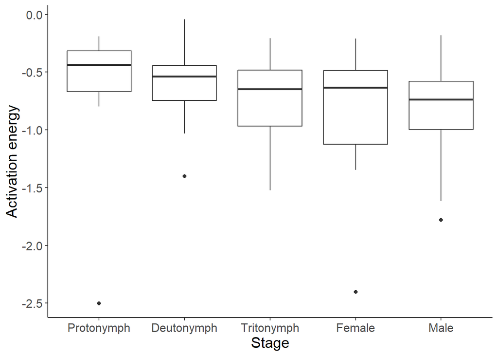

```r
## Temperature optima
ggplot(energyfinal, aes(x=stage, y=slope))+geom_boxplot() +theme_classic() +
  theme(text = element_text(size = 15))+
  xlab("Stage")+
  ylab("Activation energy") # Check what units this would be
```

### 10.3.5 Comparing max of activation energy with those of the Ropt

```r
energyfinal<-read.csv("Outputs/activation energy final.csv")

energyfinal<-energyfinal%>%
  mutate(logtime=max)

dat<-read.csv("Outputs/ToptandRopts_trim.csv")


energycheck<-difference_left_join(energyfinal,dat, by=c("ind", "logtime"), max_dist=0.13) #Merges dataframes based on the closest logtime value (within 0.13)

energycheck<-energycheck %>%
  mutate(diff=round(logtime.x-logtime.y, digits=3))
```

There is no difference (diff=0) as it should be. This means there is a match between the topt and the maximum point of the estimation of the slope line that leads to the activation energy.